# Trace amine-associated receptor 1 (TAAR1) agonists for psychosis - Results from the human studies

Version 2 (preliminary)

The first and the updated versions were drafted by Spyridon Siafis, with inputs and comments by Virginia Chiocchia, Claire Friedrich, Jaycee Kennett, Charlotte Austin, Robert R McCutcheon, Georgia Salanti, Stefan Leucht.

3 Jul 2025

# 1. Description of changes from the previous version and methodological approach

## 1.1 Changes and updates from the previous version

This is the second iteration of the review, please see the previously published and first iteration in (Siafis et al. 2024). The same methodology was followed as the first iteration, and data from the updated search were incorporated.

## 1.2 Methodological approach

1. We searched for all controlled and uncontrolled studies examining TAAR1 agonists. In the first and second iteration of the review, we analyzed usable data from all randomized controlled studies comparing any TAAR1 agonist to placebo or current antipsychotics in people with psychosis, other mental health conditions, or healthy volunteers. We did not include uncontrolled studies, except for mechanistic insights (see the extended data for additional explanations).
2. We examined efficacy outcomes, including overall symptoms of psychosis (primary outcome) and symptom domains, dropouts due to any reason, and adverse events. Safety outcomes included death, serious adverse events, and specific adverse events. We also sought mechanistic outcomes, specifically neurobiological measures of dopaminergic, glutamatergic, and serotonergic signalling. We examined these outcomes at three time points: immediately after a single dose up to 2 weeks of treatment, 3-13 weeks of treatment (preferably at 6 weeks), and longer-term outcomes.
3. In terms of efficacy outcomes, we pooled the data for each specific subgroup, considering that differences can be expected among different diagnoses (e.g., schizophrenia and Parkinson’s disease psychosis) and patient subgroups (e.g., patients with an acute episode of schizophrenia or with predominant negative symptoms). In terms of other outcomes, we combined data from all subgroups but also presented data separately for each subgroup.
4. Summary of data extraction: For continuous outcomes, we preferred change over endpoint scores and data from appropriate models or imputations considering missing outcome data. For dichotomous outcomes, we again preferred data from all participants, but in case of participants with missing outcome data, we assumed that they did not experience the event; an assumption usually used in meta-analysis in schizophrenia (e.g., Huhn et al. (2019)). In terms of crossover studies, we preferred data from appropriate models considering period or carry-over effects. If not available, we assumed a correlation (i.e., 0.2 for adverse events) to correct the variance of the estimates according to Elbourne et al. (2002) . If an outcome was measured multiple times after a single dose of the drug, we calculated the area under the curve according to the linear trapezoid rule (Chiou 1978) and divided by the time of assessment to remove the time component.
5. Risk of bias was assessed using the RoB2 tool (Sterne et al. 2019) for parallel and crossover studies. When only one domain had some concerns, we assigned an overall low risk of bias. Otherwise, we used the worst judgment across domains.
6. The effect sizes were as follows: 1) standardized mean differences (SMD) for efficacy outcomes, given that various scales have been used in the literature to allow comparability of the findings with other studies of antipsychotic drugs; 2) mean differences (MD) for laboratory measures, i.e., weight (kg), QTc interval (msec), and prolactin levels (ng/ml); 3) odds ratios (OR) for dichotomous outcomes, which were also converted to absolute risks using a control event rate (S. Leucht et al. 2022). 95% confidence intervals (95% CI) are presented, but 95% prediction intervals are not presented due to the small number of studies. Other effect sizes were not used in the first and second iteration of the review, e.g., those used in meta-analysis of variance due to the paucity of data.
7. Meta-analysis was conducted primarily using a random-effects model with inverse variance and REML estimator of tau-squared. Due to the small number of studies (<5) in all analyses, we did not correct the confidence intervals using the Hartung-Knapp method (IntHout, Ioannidis, and Borm 2014), and we also presented the findings from fixed-effects models using the Mantel-Haenszel method throughout. Meta-analysis of proportions was conducted to pool the control groups to estimate the control event rate using logit transformation of the proportions and inverse variance method (Schwarzer et al. 2019). Moreover, continuity corrections of 0.5 were applied in case of 0 events in one of the groups.
8. Sensitivity analysis of the primary outcome included using fixed-effect methods (*post-hoc* due to the small number of studies), restricting the analysis to studies with an overall low risk of bias, and excluding studies with imputed values. A *post-hoc* sensitivity analysis was also conducted in this iteration to examine the potential impact of omitting the findings of a prematurely terminated study (Sumitomo 2024) on the summary effects of the primary outcome.
9. Subgroup analyses and meta-regressions were not conducted due to the paucity of data. However, we explored potential dose-effects for the primary outcome by plotting the effect sizes for different fixed doses of TAAR1 agonists compared to placebo (while correcting for the use of common comparators (Higgins et al. 2019)).
10. Summary of evidence tables were constructed for all outcomes, including a summary of the association, within-study biases, across-study biases, biases due to indirectness, and other biases. We used the RoB2 tool (Sterne et al. 2019) to assess within-study biases, as mentioned above. We used the ROB-ME approach (Matthew J. Page et al. 2023) for evaluating biases in missing evidence and across-study biases. Indirectness was considered especially relevant for non-efficacy outcomes, where we pooled data across diagnoses and subgroups, and considered the percentage of studies and participants with schizophrenia, the main group for which this evidence would be applicable.
11. Finally, as there were no usable data from controlled experimental studies on the effects of TAAR1 agonists on neurobiological measures relevant to dopaminergic, serotonergic, or glutamatergic signalling, we could not analyze them as secondary outcomes in the current review. Nevertheless, to provide mechanistic insights, we narratively described the findings of any available mechanistic data from controlled and uncontrolled studies, irrespective of their inclusion in this review, given that we had comprehensively searched for them (Siafis et al. 2023). We also presented the findings of these studies narratively in summary of evidence tables and discussed potential issues of risk of bias, reporting bias, indirectness, and other biases, but without formally using risk of bias tools.

*Please see the manuscript, extended data (*https://osf.io/tdmau/*), the protocol (Siafis et al. 2023) and the publication of the first iteration (Siafis et al. 2024) for more details.*

*A list of abbreviations can be find towards the end of the document.*

**We present below the results, including the PRISMA flow diagram (Matthew J. Page et al. 2021) , table of included studies, risk of bias assessment, and forest plots, to facilitate a better understanding of the summary of evidence tables and the manuscript. Please refer to the detailed description of the findings in the latter part of the manuscript for more information.**

# 2. Flow of study selection

**The current flow diagram presented below reflects that of the previous version of the review. It is currently being updated.**

[interactive chart not shown]

**Figure 1** PRISMA 2020 flow diagram. *It should be noted that due to the limited data on mechanistic insights, we also presented narratively the findings from one of the excluded uncontrolled studies, since this was the only molecular neuroimaging study Sumitomo Pharma America (2023a); this study is listed along with the 26 excluded studies due to wrong study design in the PRISMA flow diagram.

# 3. Table of included studies

| Name | Title | ID | Sponsor | Design | Population | Intervention | Sample size | Objectives | Start date | Completion date | Completion year | Status | Available data |
| --- | --- | --- | --- | --- | --- | --- | --- | --- | --- | --- | --- | --- | --- |
| *NCT04038957 | A Clinical Study to Investigate the Effect of an Investigational Drug as an Added Medication to an Antipsychotic, in Adults With Schizophrenia, as Measured Positron Emission Tomography (PET) Imaging | SEP361-118, NCT04038957, 2019-000568-65 | Sunovion/Sumitomo; Otsuka | Open single-arm study; 2 weeks (phase 1) | Men/women 18-65 year with schizophrenia (stable, DSM-5) | Ulotaront 50-75mg/d (add-on to current antipsychotic treatment) | 22 | F-DOPA PET | August 7, 2019 | June 6, 2023 | 2023 | completed | F-DOPA (narratively) |
| DA801002 (in Galluppi 2021) | Population pharmacokinetic analysis of ulotaront in subjects with schizophrenia | DA801002 | Sunovion/Sumitomo | SB-RCT single ascending dose (phase I) | Men >18 years | Ulotaront (25mg to 50mg); Placebo | 16 | Pharmacokinetics | NA | NA | 2021 | completed | None |
| Fowler (2015) | A UGT2B10 Splicing Polymorphism Common in African Populations May Greatly Increase Drug Exposure | NA | Hoffmann-La Roche | DB-RCT; single ascending dose (phase I) | Men 18-45 years | RO5263397 (1mg to 125mg); Placebo | 49 | Tolerability, pharmacokinetics | NA | NA | 2015 | completed | None |
| Hopkins (2021) | Effect of TAAR1/5-HT1A agonist SEP-363856 on REM sleep in humans | SEP361-103 | Sunovion/Sumitomo; Otsuka | DB-RCT two-period crossover; single dose (phase I) | Men 18-35 years | Cohort 1: Ulotaront 10mg; Placebo; Cohort 2: Ulotaront 50mg; Placebo | 24 | Sleep parameters, pharmacokinetics | NA | NA | 2021 | completed | Dropouts, side-effects |
| Isaacson (2023) | Ulotaront, a Trace Amine-Associated Receptor 1/Serotonin 5-HT1A Agonist, in Patients With Parkinson Disease Psychosis: A Pilot Study. | SEP361-203, NCT02969369 | Sunovion/Sumitomo; Otsuka | DB-RCT; 6 weeks (with open label extension) (phase 2) | Men/women ≥55 years with Parkinson’s disease psychosis (acute) | Ulotaront 20-75mg/d; Placebo | 39 | Efficacy (acute), tolerability | November 21 2016 | July 5 203 | 2023 | completed | Efficacy, dropouts, side-effects |
| JapicCTI-194581 (2019) | A Phase I Single-Ascending Dose and Multiple-Ascending Dose Study of RO6889450 in Healthy Japanese Male | JapicCTI-194581 | Hoffmann-La Roche | DB-RCT; single and multiple ascending dose (phase I) | Men 20-45 years | Ralmitaront; Placebo | 64 | Tolerability, pharmacokinetics | January 27 2019 | October 2023 2019 | 2019 | completed | None |
| Koblan (2016) | A phase 1 open label safety and tolerability study of SEP-363856, a novel NON-D2 mechanism of action molecule, in patients with schizophrenia | SEP361-106, NCT01994473 | Sunovion/Sumitomo; Otsuka | SB-RCT; multiple ascending dose for 1 week (including open label extension) (phase 1) | Men/women 18-55 years with schizophrenia (stable, DSM-IV-TR) | Ulotaront (10mg/d to 100mg/d); Placebo | 48 | Tolerability, pharmacokinetics | October 1 2013 | December 1 2014 | 2014 | completed | None |
| Koblan (2020) | A Non–D2-Receptor-Binding Drug for the Treatment of Schizophrenia | SEP361-201, NCT02969382, EUCTR2016-001555-41 | Sunovion/Sumitomo; Otsuka | DB-RCT; 4 weeks (with open label extension) (phase 2) | Men/women 18-40 years with schizophrenia (acute, DSM-5) | Ulotaront (50-75mg/d); Placebo | 245 | Efficacy (acute), tolerability | December 5 2016 | July 21 2018 | 2018 | completed | Efficacy, dropouts, side-effects |
| NCT01940159 (2013) | A Study Assessing the Safety, Tolerability, and Pharmacokinetics of SEP-363856 in Male and Female Subjects With Schizophrenia | SEP361-105, NCT01940159 | Sunovion/Sumitomo; Otsuka | SB-RCT; single ascending dose (phase 1) | Men/women 18-50 years with schizophrenia (stable, DSM-IV-TR) | Ulotaront (50mg to 150mg); Placebo | 48 | Tolerability, pharmacokinetics | August 1 2013 | March 1 2014 | 2014 | completed | None |
| NCT02699372 (2016) | The Safety, Tolerability, Pharmacokinetics and Pharmacodynamics Study of RO6889450 in Healthy Volunteers | BP30134, NCT02699372 | Hoffmann-La Roche | DB-RCT; single and multiple ascending dose up to 2 weeks (phase I) | Men/women 18-45 years | Ralmitaront (5 mg to 450mg); Placebo | 164 | Tolerability, pharmacokinetics | March 21 2016 | April 17 2014 | 2017 | completed | None |
| NCT03669640 (2018) | A Study to Assess the Effects of RO6889450 (Ralmitaront) in Participants With Schizophrenia or Schizoaffective Disorder and Negative Symptoms | BP40283, NCT03669640, EUCTR2020-004752-16, JPRN-jRCT2031200287 | Hoffmann-La Roche | DB-RCT; 12 weeks (phase II) | Men/women 18-55 years with schizophrenia or schizoaffective (predominant negative symptoms, DSM-5) | Part A: Ralmitaront 150mg/d; placebo (monotherapy); Part B: Ralmitaront 45mg; Ralmitaront 150mg/d; Ralmitaront 300mg/d; placebo (add-on to current antipsychotics) | 131 | Efficacy (negative symptoms), tolerability | December 4 2018 | May 08 2023 | 2023 | terminated | Efficacy, dropouts, side-effects |
| NCT04072354 (2019) | A Clinical Trial to Study the Efficacy and Safety of an Investigational Drug in Acutely Psychotic People With Schizophrenia | SEP361-301, NCT04072354, EUCTR2019-000470-36 | Sunovion/Sumitomo; Otsuka | DB-RCT; 6 weeks (phase 3) | Men/women 13-17 and 18-65 years with schizophrenia (acute, DSM-5) | Ulotaront 50mg/d; Ulotaront 75mg/d; Placebo | 463 | Efficacy (acute), tolerability | September 11 2019 | June 8 2023 | 2023 | completed | Efficacy, dropouts |
| NCT04092686 (2019) | A Clinical Trial That Will Study the Efficacy and Safety of an Investigational Drug in Acutely Psychotic People With Schizophrenia | SEP361-302, NCT04092686, EUCTR2019-000697-37 | Sunovion/Sumitomo; Otsuka | DB-RCT; 6 weeks (phase 3) | Men/women 18-65 years with schizophrenia (acute, DSM-5) | Ulotaront 75mg/d; Ulotaront 100mg/d; Placebo | 462 | Efficacy (acute), tolerability | September 30 2019 | September 08 2023 | 2023 | completed | Efficacy, dropouts |
| NCT04115319 (2019) | A Study of the Long-term Safety and Tolerability of an Investigational Drug in People With Schizophrenia. | SEP361-304, NCT04115319 , EUCTR2019-002259-40 | Sunovion/Sumitomo; Otsuka | DB-RCT; 52 weeks (phase 3) | Men/women 18-65 years with schizophrenia (stable, DSM-5) | Ulotaront 50-100mg/d; Quetiapine XR 400-800mg/d | 302 | Efficacy (maintenance), tolerability | November 15 2019 | December 30 2022 | 2022 | completed | Efficacy, dropouts, side-effects |
| NCT04325737 (2020) | Study Assessing the Safety, Tolerability, and Pharmacokinetics of SEP-363856 in Japanese Male and Female Subjects With Schizophrenia | DA801102, NCT04325737, jRCT2080225100 | Sunovion/Sumitomo | DB-RCT; 2 weeks (phase 1) | Men/women 18-65 years with schizophrenia (stable, DSM-5) | Cohort 1: Ulotaront (50mg/d to 100mg/d); Placebo; Cohort 2: Ulotaront (25mg/d to 100mg/d); Placebo | 13 | Tolerability, pharmacokinetics | March 31 2020 | August 7 2020 | 2020 | completed | None |
| NCT04512066 (2020) | A Trial of the Efficacy and the Safety of RO6889450 (Ralmitaront) vs Placebo in Patients With an Acute Exacerbation of Schizophrenia or Schizoaffective Disorder | BP41743, NCT04512066, JPRN-jRCT2031200288 | Hoffmann-La Roche | DB-RCT; 4 weeks (up to 48 weeks extension) (phase II) | Men/women 18-45 years with schizophrenia or schizoaffective disorder (acute, DSM-5) | Ralmitaront 45mg/d; Ralmitaront 150mg/d; Risperidone 4mg/d; Placebo | 287 | Efficacy (acute), tolerability | September 8 2020 | June 21 2022 | 2022 | completed | Efficacy, dropouts, side-effects |
| NCT04825860 (2021) | A Clinical Trial to Evaluate the Efficacy and Safety of SEP-363856 in Acutely Psychotic People With Schizophrenia, Followed by an Open-label Extension Phase | DA801201, NCT04825860, jRCT2071210003 | Sunovion/Sumitomo | DB-RCT; 6 weeks (and open label extension) (phase 2/3) | Men/women 18-65 years with schizophrenia (acute, DSM-5) | Ulotaront 50mg/d; Ulotaront 75mg/d; Placebo | 83 | Efficacy (acute), tolerability | March 29 2021 | October 19 2023 | 2023 | terminated | None |
| NCT05402111 (2022) | A Clinical Study That Will Assess How Food Moves Through the Stomach and Effects Blood Glucose Levels in Subjects With Schizophrenia Taking SEP-363856 or and Prior Antipsychotic (PA) Standard | SEP361-124, NCT05402111 (2022) | Sunovion/Sumitomo; Otsuka | Open RCT two-period crossover; single dose (phase 1) | Men/women 18-65 years with schizophrenia (stable, DSM-5) and metabolic syndrome | Ulotaront 150mg; Prior antipsychotics (risperidone, olanzapine, quetiapine, aripiprazole) | 31 | Pharmacokinetics, metabolic parameters | June 13 2022 | September 29 2023 | 2023 | completed | Side-effects |
| NCT05542264 (2022) | A Clinical Study That Will Assess the Effect of SEP-363856 or Prior Antipsychotic (PA) Standard of Care on Body-weight Associated Parameters in Subjects With Schizophrenia | SEP361-122, NCT05542264 | Sunovion/Sumitomo; Otsuka | DB-RCT; 2 weeks up to 13 weeks (phase 1) | Men/women 18-65 years with schizophrenia (stable, DSM-5) and metabolic syndrome | Ulotaront; Prior antipsychotics (risperidone, olanzapine, quetiapine, aripiprazole) | 19 | Metabolic parameters | November 15 2022 | February 12 2024 | 2024 | completed | None |
| NCT05593029 (2022) | A Trial of the Safety and Efficacy of SEP-363856 in the Treatment of Adults With Major Depressive Disorder | 382-201-00001, NCT05593029 | Sunovion/Sumitomo; Otsuka | DB-RCT; 14 weeks (phase 2/3) | Men/women 18-65 years with MDD (acute, DSM-5) | Ulotaront; Placebo (add-on to antidepressants) | 1030 | Efficacy (MDD), tolerability | November 9 2022 | February 01 2026 | NA | ongoing | None |
| NCT05729373 (2023) | A Clinical Study That Will Meaure How Well SEP-363856 Works and How Safe it is in Adults With Generalized Anixety Disorder | SEP361-226, NCT05729373, EUCTR2022-502077-42-00 | Sunovion/Sumitomo; Otsuka | DB-RCT; 8 weeks (phase 2/3) | Men/women 18-65 years with GAD (acute, DSM-5) | Ulotaront (50-75mg/d); Placebo | 464 | Efficacy (GAD), tolerability | March 8 2023 | February 08 2026 | NA | ongoing | None |
| NCT05848700 (2023) | A Clinical Study to Learn if SEP-363856 Has Physical Dependence in Adults With Schizophrenia | SEP361-121, NCT05848700 | Sunovion/Sumitomo; Otsuka | DB-RCT; 10 weeks (phase 1) | Men/women 18-65 years with schizophrenia (stable, DSM-5) | Ulotaront continuation; Ulotaront discontinuation (switch to placebo) | 60 | Physical dependence, pharmacokinetics | June 21 2023 | March 15 2024 | 2024 | completed | None |
| NCT06880328 (2019) | 18F-Dihydroxyphenylalanine (DOPA) Positron Emission Tomography (PET) Study to Explore Dopamine Synthesis Capacity in the Whole Striatum After 2 Weeks of Treatment With Ralmitaront or Placebo in Partic… | BP39833 | Hoffmann-La Roche | DB-RCT two-period crossover; 2 weeks (phase 1) | Men/women 18-65 years with schizophrenia (stable, DSM-5) | Ralmitaront 150 mg/d; Placebo | 35 | F-DOPA PET; fMRI; tolerability | November 07 2018 | September 04 2019 | 2019 | completed | None |
| NCT06894212 (2025) | A Trial of the Efficacy and Safety of SEP-363856 in Acutely Psychotic Participants With Schizophrenia | 382-201-00035 | Otsuka | DB-RCT; 6 weeks (phase 3) | Men/women 18-65 years with schizophrenia (acute, DSM-5) | Ulotaront 75mg; Ulotaront 100mg; Placebo | 522 | Efficacy (acute), tolerability | February 25 2025 | August 31 2028 | NA | ongoing | None |
| Perini (2023) | Effects of ulotaront on brain circuits of reward, working memory, and emotion processing in healthy volunteers with high or low schizotypy | SEP361-104, NCT01972711 | Sunovion/Sumitomo; Otsuka | DB-RCT; single dose (phase 1) | Men/women 18-45 years (high or low levels of schizotypy) | Ulotaront 50mg; Amisulpride 400mg; Placebo | 105 | fMRI | March 1 2014 | July 1 2015 | 2015 | completed | Dropouts, side-effects, fMRI (narratively) |
| SEP361-101 (in Galluppi 2021 and Chen 2022) | A sensitive LC-MS/MS method for simultaneous quantification of ulotaront and its N-desmethyl metabolite in human plasma and application to a clinical study | SEP361-101 | Sunovion/Sumitomo; Otsuka | SB-RCT; single ascending dose (phase I) | Men >18 years | Ulotaront (5mg to 125mg); Placebo | 52 | Pharmacokinetics | NA | NA | 2021 | completed | None |
| Szabo (2023) | A multicenter, double-blind, placebo-controlled, randomized, Phase 1b crossover trial comparing two doses of ulotaront with placebo in the treatment of narcolepsy-cataplexy. | SEP361-108 , NCT05015673 | Sunovion/Sumitomo; Otsuka | DB-RCT three-period crossover; 2 weeks (phase 1) | Men/women 18-55 years with narcolepsy/cataplexy | Ulotaront 25mg; Ulotaront 50mg; Placebo | 18 | Sleep parameters, pharmacokinetics, tolerability | June 5 2014 | May 26 2015 | 2015 | completed | Dropouts, side-effects |
| Tsukada (2023) | A randomized, single-dose, crossover study of the effects of ulotaront on electrocardiogram intervals in subjects with schizophrenia. | SEP361-114, NCT04369391 | Sunovion/Sumitomo; Otsuka | DB-RCT three-period crossover; single dose (phase 1) | Men/women 18-65 years with schizophrenia (stable, DSM-5) | Ulotaront 150mg; Placebo; Moxifloxacin 400mg (ineligible for the review) | 68 | QTc interval, tolerability, pharmacokinetics | June 18 2020 | November 10 2020 | 2020 | completed | Dropouts, side-effects |

**Table 1** Table of included studies. Since March 2024, Otsuka holds the exclusive rights for ulotaront worldwide after revision of the license agreement with Sumitomo.*It should be noted that due to the limited data on mechanistic insights, we also presented narratively the findings from one of the excluded uncontrolled studies, since this was the only molecular neuroimaging study (Sumitomo Pharma America 2023a), which characteristics are also presented here as an exception along with the included RCTs. SB: Single-Blind, DB: Double-Blind, DSM: Diagnostic and Statistical Manual for Mental Disorders, RCT: Randomized controlled trial, MDD: Major Depressive Disorder, GAD: Generalzied Anxiety Disorder, fMRI: functional neuroimaging, PET: Positron emission tomography.

# 4. Description of included studies

The studies used to describe mechanistic insights are provided in the relevant section below. It should be noted that the findings from an additional single-arm molecular neuroimaging are described in this section (Sumitomo Pharma America 2023a), which was uncontrolled and formally excluded from this iteration of the review. The characteristics of this study and its findings are described in the “mechanistic insights” section.

## 4.1 Completed studies with usable data

There were usable data for this analysis from 12 studies (1683 participants) (Hopkins, Dedic, and Koblan 2021; Isaacson et al. 2023; Koblan et al. 2020; Sumitomo Pharma America 2023b, 2023c; Roche 2022; Perini et al. 2023; Szabo et al. 2023; Tsukada et al. 2023; Milanović et al. 2024; Otsuka Pharmaceutical Development & Commercialization, Inc 2024b; Hoffmann-La Roche 2024), which enrolled adult populations across multiple countries and were funded by the industry manufacturing the TAAR1 agonists.

### 4.1.1 Studies examining multiple doses of TAAR1 agonists

The usable studies compared single or multiple doses of two TAAR1 agonists (i.e., ulotaront or ralmitaront) with placebo or current antipsychotics (i.e., prior antipsychotics, risperidone, amisulpride or quetiapine) in people with schizophrenia, Parkinson’s disease psychosis, other mental health conditions (narcolepsy/cateplexy as sleep disorder) and healthy volunteers.

### 4.1.2 Studies examining single doses of TAAR1 agonists

*Five studies* examined the pharmacokinetics, safety and/or neuroimaging of single doses of TAAR1 agonists or multiple doses for up to 2 weeks:

- *One study* examining the effects of a single dose of 150mg ulotaront in clinically stable adults with schizophrenia on QTc interval within a day (Tsukada et al. 2023). The study utilized a three-period crossover period comparing ulotaront with placebo and moxifloxacin (an antibiotic used as active comparator, not relevant for our analysis).
- *Two studies* examined the effects of single doses of ulotaront in healthy volunteers on sleep parameters (Hopkins, Dedic, and Koblan 2021) or fMRI tasks (Perini et al. 2023). Hopkins, Dedic, and Koblan (2021) included two cohorts of crossover studies comparing two single doses of ulotaront with placebo. (Perini et al. 2023) was a parallel trial comparing ulotaront to placebo or the antipsychotic amisulpride on fMRI tasks relevant to reward, working memory and emotion processing in volunteers with high or low schizotypy traits.
- *One study* examined two single doses of ulotaront in adults with narcolepsy-cateplexy compared to placebo using a three-period crossover design (Szabo et al. 2023).
- *One study* examined the effects of a single dose of ulotaront compared to previous antipsychotics (aripiprazole, olanzapine, risperidone or quetiapine) in adults with schizophrenia and concurrent metabolic syndrome on gastric emptying using a crossover design (Milanović et al. 2024).

## 4.2 Completed studies with unavailable data

Data from the following studies were unavailable:

## 4.3 Ongoing studies

The following studies are ongoing:

- *One study* is examining the efficacy and safety of ulotaront 75 mg/day and 100 mg/day compared to placebo in 522 adults with acute schizophrenia (NCT06894212). The trial is expected to be completed in 2028.
- *Two studies* are examining the efficacy and safety of ulotaront compared to placebo in other mental health conditions, i.e., adults with major depression (NCT05593029) and generalized anxiety disorder (NCT05729373). These trials are expected to be completed in 2025-2026, and their safety data are relevant for this review.

# 5. Risk of bias assessment

The risk of bias of the studies was examined using the RoB2 tool (Sterne et al. 2019) for parallel and crossover studies for all outcomes. Here, we present the risk of bias of using the worst judgement of a domain across outcomes. It should be noted that when there were some concerns in only one of the domains, we assigned an overall low risk of bias according to our protocol.

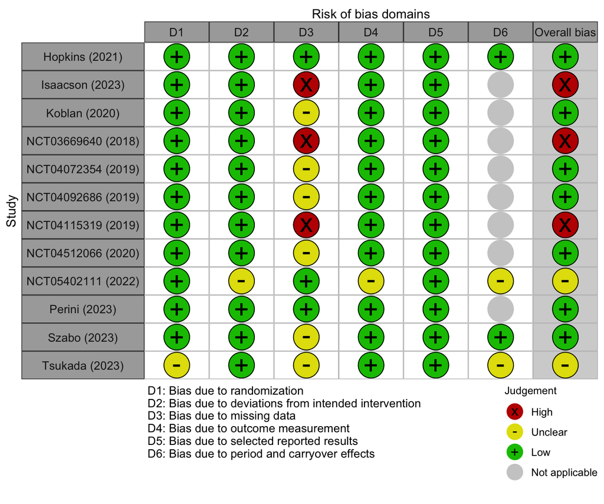

**Figure 2** Risk of bias of studies with usable data

All the studies were double-blind randomized controlled studies, with a low risk of bias in most cases in their respective domains of biases due to randomization, deviations from intended interventions, and outcome measurement. An exception was one open-label crossover study examining a single dose of ulotaront versus previous antipsychotics (Milanović et al. 2024). There were also no indications of selectively reported results; thus, the studies had a low risk of bias in their respective domains. Most of the studies had missing outcome data, but there was no clear indication that the missingness depended on the true value of the effects for most of the outcomes. Therefore, there were some concerns, except for (Isaacson et al. 2023; Hoffmann-La Roche 2024; Otsuka Pharmaceutical Development & Commercialization, Inc 2024b) , which had a high risk of bias for efficacy outcomes but not for adverse events and other outcomes. Additionally, there were few differences in this domain across outcomes, such as a low risk for the outcome of dropouts. In terms of the four crossover studies, there was a low risk of bias in period and carry-over effects, except for some concerns in the three-period crossover study of Tsukada et al. (2023) and the open-label crossover study of Milanović et al. (2024). Few differences across outcomes can be found in the overall judgment of the risk of bias for each study per outcome in the respective forest plots below.

# 6. Results for the comparisons

**It should be noted that the x-axis in the figures below, which present dichotomous outcomes using odds ratios, is logarithmically scaled.** **When the forest plots present only the effect sizes, there were crossover studies in which variances were corrected assuming a correlation of 0.2.**

## 6.1 *TAAR1 agonist* vs *placebo (monotherapy)*

This section refers to the comparson of TAAR1 agonists versus placebo as monotherapy. See comparison 6.3 for TAAR1 agonists versus placebo as adjunctive treatment to antipsychotics.

### 6.1.1 Overall symptoms (primary outcome)

#### Timepoint 1: *1 day - 2 weeks*

No usable data available from RCT.

#### Timepoint 2: *3 weeks - 13 weeks*

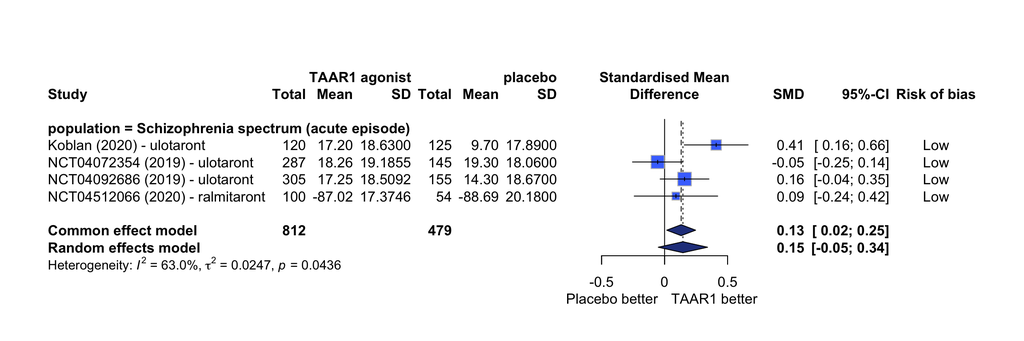

**Figure 3a** Forest plot for overall symptoms (primary outcome, measured with PANSS total) for the comparison of TAAR1 agonist vs. placebo in people with acute episode of schizophrenia at 3-13 weeks (primary timepoint). The overall risk of bias of the studies for this outcome is presented. SMD:Standardized mean difference, 95%CI: 95% confidence intervals, SD: Standard deviation.

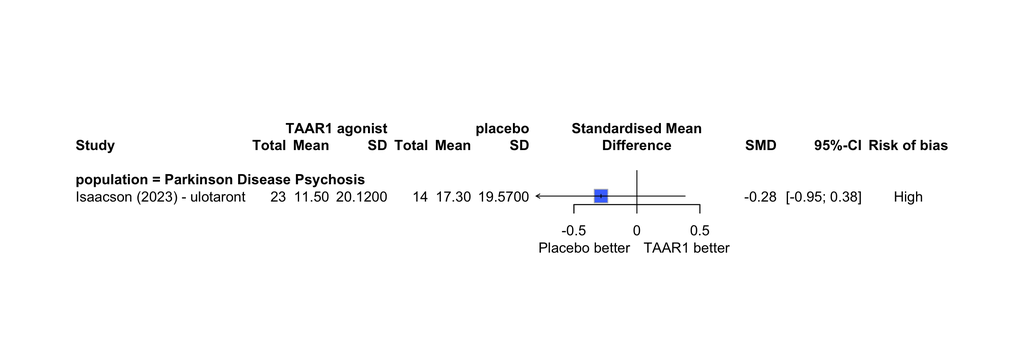

**Figure 3b** Forest plot for overall symptoms (primary outcome, measured with the NPI total score) for the comparison of TAAR1 agonist vs. placebo in people with Parkinson’s disease psychosis at 3-13 weeks (primary timepoint). The overall risk of bias of the studies for this outcome is presented. SMD:Standardized mean difference, 95%CI: 95% confidence intervals, SD: Standard deviation.

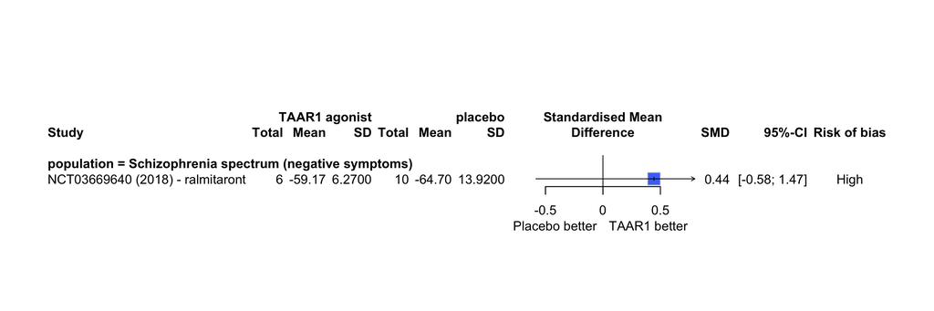

**Figure 3c** Forest plot for overall symptoms (primary outcome, measured with PANSS total) for the comparison of TAAR1 agonist vs. placebo in people with schizophrenia and negative symptoms at 3-13 weeks (primary timepoint). The overall risk of bias of the studies for this outcome is presented. SMD:Standardized mean difference, 95%CI: 95% confidence intervals, SD: Standard deviation.

#### Timepoint 3: *> 13 weeks*

No usable data available from RCT.

### 6.1.2 Positive symptoms

#### Timepoint 1: *1 day - 2 weeks*

No usable data available from RCT.

#### Timepoint 2: *3 weeks - 13 weeks*

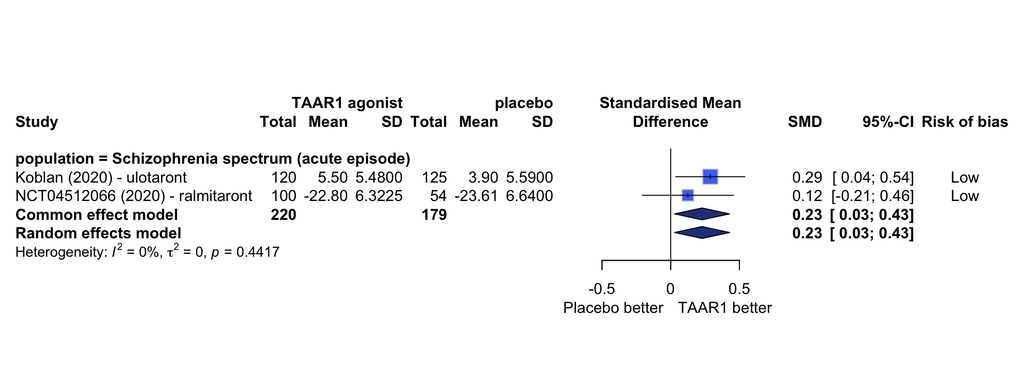

**Figure 4a** Forest plot for positive symptoms for the comparison of TAAR1 agonist vs. placebo in people with acute episode of schizophrenia (measured with PANSS positive) at 3-13 weeks (primary timepoint). The overall risk of bias of the studies for this outcome is presented. SMD:Standardized mean difference, 95%CI: 95% confidence intervals, SD: Standard deviation.

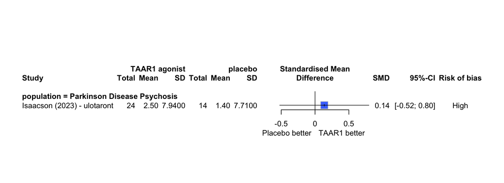

**Figure 4b** Forest plot for positive symptoms for the comparison of TAAR1 agonist vs. placebo in people with Parkinson’s disease psychosis (measured with SAPS-PD) at 3-13 weeks (primary timepoint). The overall risk of bias of the studies for this outcome is presented. SMD:Standardized mean difference, 95%CI: 95% confidence intervals, SD: Standard deviation.

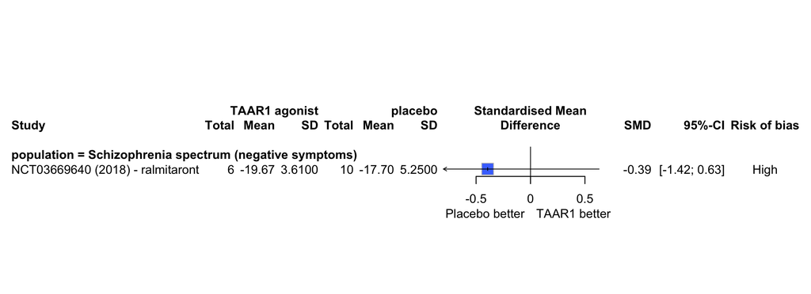

**Figure 4c** Forest plot for positive symptoms for the comparison of TAAR1 agonist vs. placebo in people with schizophrenia and negative symptoms (measured with PANSS positive Marder factor) at 3-13 weeks (primary timepoint). The overall risk of bias of the studies for this outcome is presented. SMD:Standardized mean difference, 95%CI: 95% confidence intervals, SD: Standard deviation.

#### Timepoint 3: *> 13 weeks*

No usable data available from RCT.

### 6.1.3 Negative symptoms

#### Timepoint 1: *1 day - 2 weeks*

No usable data available from RCT.

#### Timepoint 2: *3 weeks - 13 weeks*

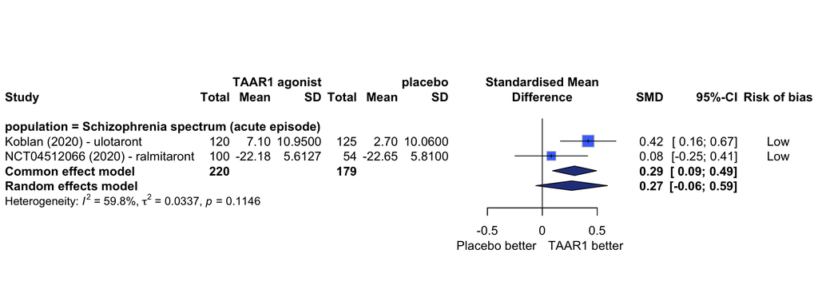

**Figure 5a** Forest plot for negative symptoms for the comparison of TAAR1 agonist vs. placebo (measured with BNSS or PANSS negative) in adutls with acute schizophrenia at 3-13 weeks (primary timepoint). The overall risk of bias of the studies for this outcome is presented. SMD:Standardized mean difference, 95%CI: 95% confidence intervals, SD: Standard deviation.

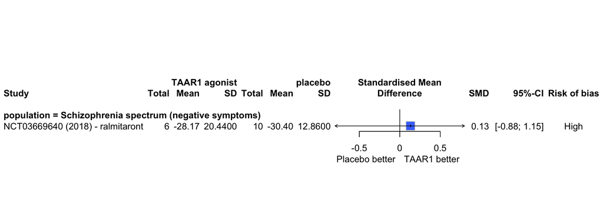

**Figure 5b** Forest plot for negative symptoms for the comparison of TAAR1 agonist vs. placebo (measured with PANSS negative Marder factor) in adults with schizophrenia and negative symptoms at 3-13 weeks (primary timepoint). The overall risk of bias of the studies for this outcome is presented. SMD:Standardized mean difference, 95%CI: 95% confidence intervals, SD: Standard deviation.

#### Timepoint 3: *> 13 weeks*

No usable data available from RCT.

### 6.1.4 Depressive symptoms

#### Timepoint 1: *1 day - 2 weeks*

No usable data available from RCT.

#### Timepoint 2: *3 weeks - 13 weeks*

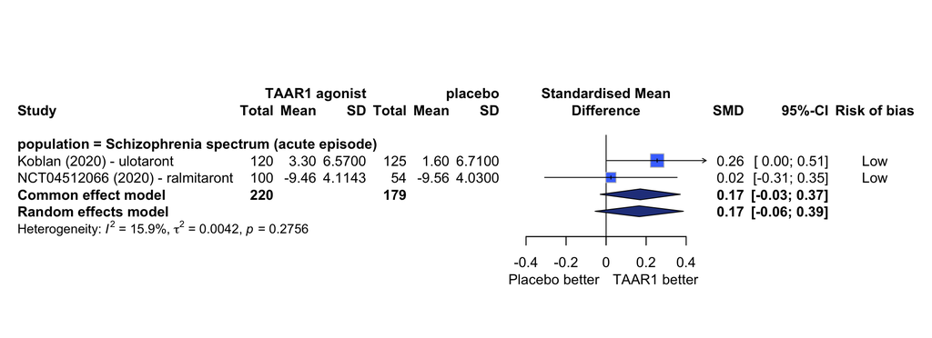

**Figure 6** Forest plot for depressive symptoms for the comparison of TAAR1 agonist vs. placebo (measured with PANSS anxiety/depression factor) at 3-13 weeks (primary timepoint). The overall risk of bias of the studies for this outcome is presented. SMD:Standardized mean difference, 95%CI: 95% confidence intervals, SD: Standard deviation.

#### Timepoint 3: *> 13 weeks*

No usable data available from RCT.

### 6.1.5 Cognitive symptoms

#### Timepoint 1: *1 day - 2 weeks*

No usable data available from RCT.

#### Timepoint 2: *3 weeks - 13 weeks*

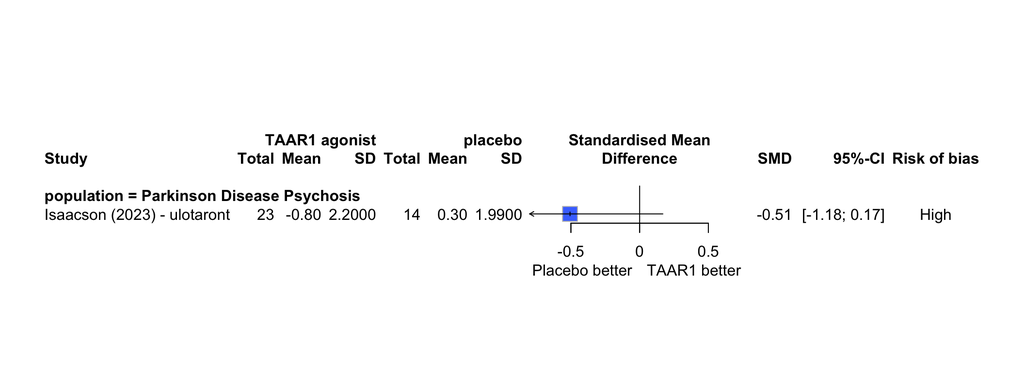

**Figure 7** Forest plot for cognitive impairment for the comparison of TAAR1 agonist vs. placebo (measured with MMSE) at 3-13 weeks (primary timepoint). The overall risk of bias of the studies for this outcome is presented. SMD:Standardized mean difference, 95%CI: 95% confidence intervals, SD: Standard deviation.

#### Timepoint 3: *> 13 weeks*

No usable data available from RCT.

### 6.1.6 Quality of life

#### Timepoint 1: *1 day - 2 weeks*

No usable data available from RCT.

#### Timepoint 2: *3 weeks - 13 weeks*

No usable data available from RCT.

#### Timepoint 3: *> 13 weeks*

No usable data available from RCT.

### 6.1.7 Functioning

#### Timepoint 1: *1 day - 2 weeks*

No usable data available from RCT.

#### Timepoint 2: *3 weeks - 13 weeks*

No usable data available from RCT.

#### Timepoint 3: *> 13 weeks*

No usable data available from RCT.

### 6.1.8 Response to treatment

#### Timepoint 1: *1 day - 2 weeks*

No usable data available from RCT.

#### Timepoint 2: *3 weeks - 13 weeks*

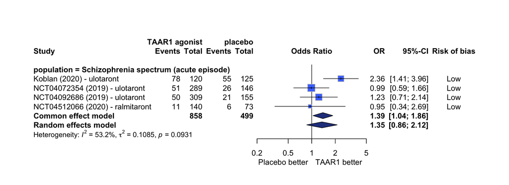

**Figure 8a** Forest plot for response (>50% or 20% symptom reduction in PANSS total from baseline) for the comparison of TAAR1 agonist vs. placebo in adults with acute episode of schizophrenia at 3-13 weeks (primary timepoint). The overall risk of bias of the studies for this outcome is presented. OR=Odds ratio, 95%CI: 95% confidence intervals.

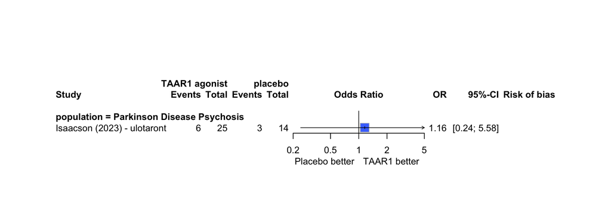

**Figure 8b** Forest plot for response (>50% symptom reduction in SAPS-PD from baseline) for the comparison of TAAR1 agonist vs. placebo in people with Parkinson’s disease psychosis at 3-13 weeks (primary timepoint). The overall risk of bias of the studies for this outcome is presented. OR=Odds ratio, 95%CI: 95% confidence intervals.

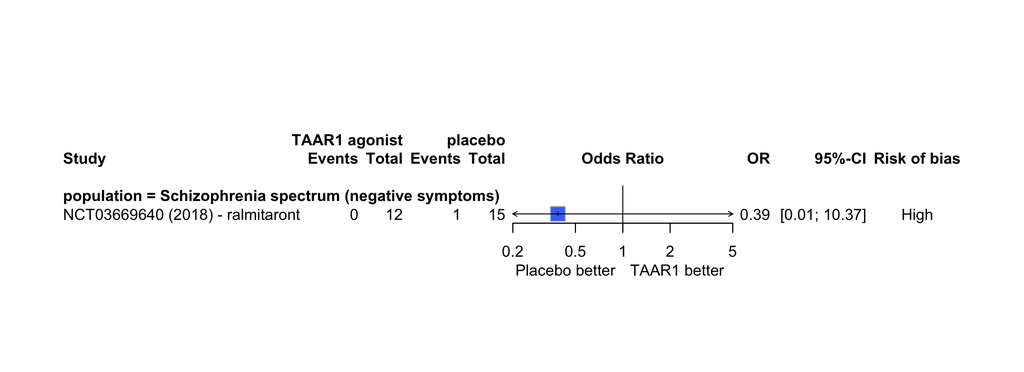

**Figure 8c** Forest plot for response (imputed; >50% symptom reduction in PANSS total from baseline) for the comparison of TAAR1 agonist vs. placebo in adults with schizophrenia and negative symptoms at 3-13 weeks (primary timepoint). The overall risk of bias of the studies for this outcome is presented. OR=Odds ratio, 95%CI: 95% confidence intervals.

#### Timepoint 3: *> 13 weeks*

No usable data available from RCT.

### 6.1.9 Relapse

#### Timepoint 1: *1 day - 2 weeks*

No usable data available from RCT.

#### Timepoint 2: *3 weeks - 13 weeks*

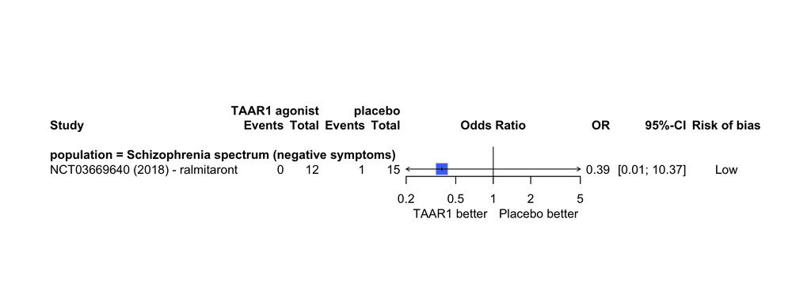

**Figure 9** Forest plot for relapse (defined as dropouts due to relapse) for the comparison of TAAR1 agonist vs. placebo in adults with schizophrenia and negative symptoms at 3-13 weeks (primary timepoint). The overall risk of bias of the studies for this outcome is presented. OR=Odds ratio, 95%CI: 95% confidence intervals.

#### Timepoint 3: *> 13 weeks*

No usable data available from RCT.

### 6.1.10 Dropouts due to any reason

#### Timepoint 1: *1 day - 2 weeks*

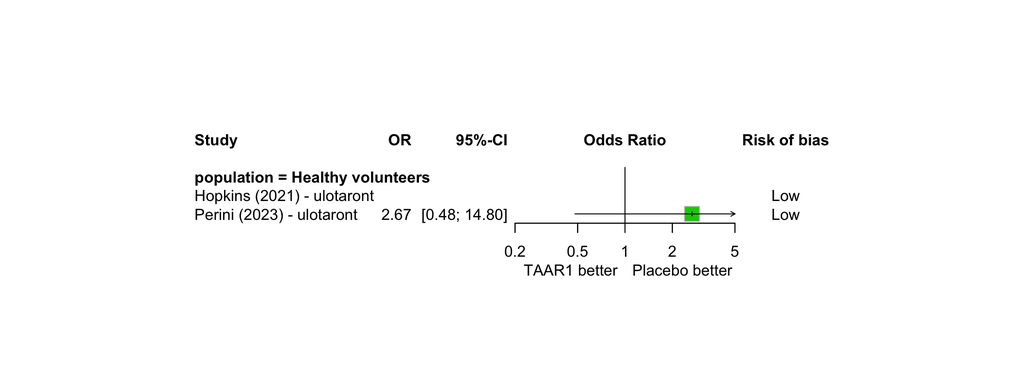

**Figure 10** Forest plot for dropouts due to any reason for the comparison of TAAR1 agonist vs. placebo at 1 day - 2 weeks. Studies with no estimable effect size had 0 events in both arms. The overall risk of bias of the studies for this outcome is presented. OR=Odds ratio, 95%CI: 95% confidence intervals.

#### Timepoint 2: *3 weeks - 13 weeks*

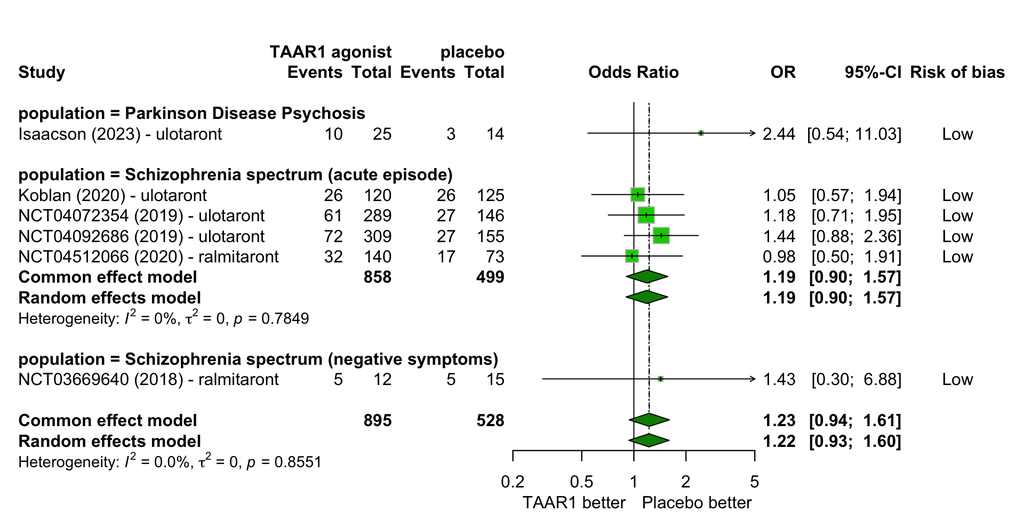

**Figure 11** Forest plot for dropouts due to any reason for the comparison of TAAR1 agonist vs. placebo at 3-13 weeks (primary timepoint). The overall risk of bias of the studies for this outcome is presented. OR=Odds ratio, 95%CI: 95% confidence intervals.

#### Timepoint 3: *> 13 weeks*

No usable data available from RCT.

### 6.1.11 Dropouts due to adverse event

#### Timepoint 1: *1 day - 2 weeks*

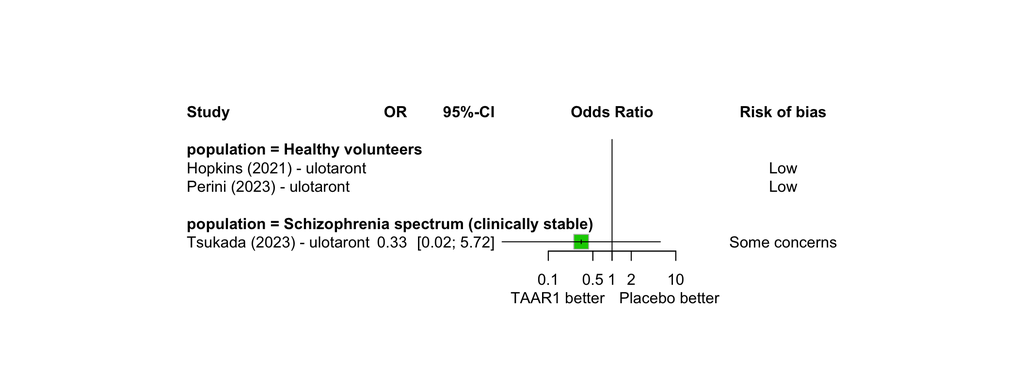

**Figure 12** Forest plot for dropouts due to adverse event for the comparison of TAAR1 agonist vs. placebo at 1 day - 2 weeks. Studies with no estimable effect size had 0 events in both arms. The overall risk of bias of the studies for this outcome is presented. OR=Odds ratio, 95%CI: 95% confidence intervals.

#### Timepoint 2: *3 weeks - 13 weeks*

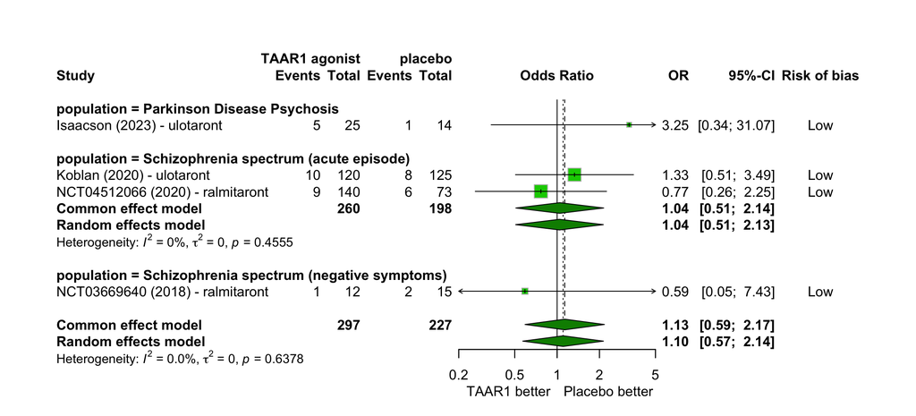

**Figure 13** Forest plot for dropouts due to adverse event for the comparison of TAAR1 agonist vs. placebo at 3-13 weeks (primary timepoint). The overall risk of bias of the studies for this outcome is presented. OR=Odds ratio, 95%CI: 95% confidence intervals.

#### Timepoint 3: *> 13 weeks*

No usable data available from RCT.

### 6.1.12 Serious adverse event

#### Timepoint 1: *1 day - 2 weeks*

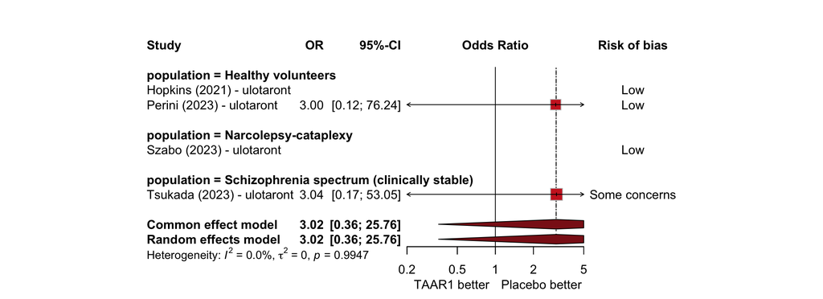

**Figure 14** Forest plot for serious adverse events for the comparison of TAAR1 agonist vs. placebo at 1 day - 2 weeks. Studies with no estimable effect size had 0 events in both arms. The overall risk of bias of the studies for this outcome is presented. OR=Odds ratio, 95%CI: 95% confidence intervals.

#### Timepoint 2: *3 weeks - 13 weeks*

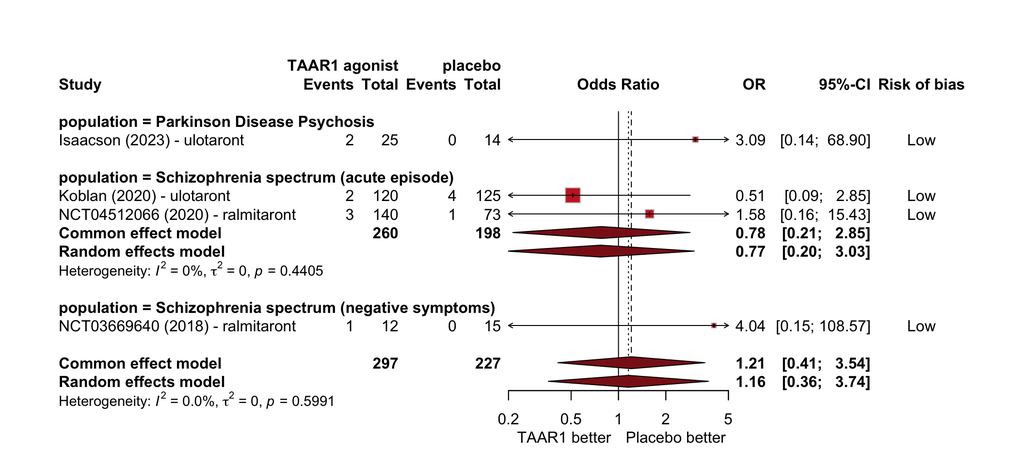

**Figure 15** Forest plot for serious adverse events for the comparison of TAAR1 agonist vs. placebo at 3-13 weeks (primary timepoint). The overall risk of bias of the studies for this outcome is presented. OR=Odds ratio, 95%CI: 95% confidence intervals

#### Timepoint 3: *> 13 weeks*

No usable data available from RCT.

### 6.1.13 Death

#### Timepoint 1: *1 day - 2 weeks*

There were available usable data from four studies (i.e., (Hopkins, Dedic, and Koblan 2021; Perini et al. 2023; Szabo et al. 2023; Tsukada et al. 2023)) but all of them reported 0 deaths so that could not provide estimable effect sizes with the current approach.

#### Timepoint 2: *3 weeks - 13 weeks*

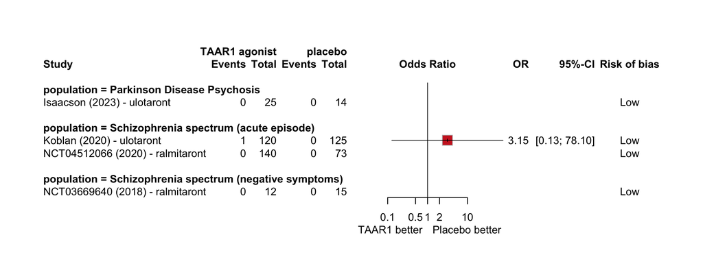

**Figure 16** Forest plot for death for the comparison of TAAR1 agonist vs. placebo at 3-13 weeks (primary timepoint). Studies with 0 events in both arms could not provide estimable effect sizes with the current approach. The overall risk of bias of the studies for this outcome is presented. OR=Odds ratio, 95%CI: 95% confidence intervals.

#### Timepoint 3: *> 13 weeks*

No usable data available from RCT.

### 6.1.14 Any adverse event

#### Timepoint 1: *1 day - 2 weeks*

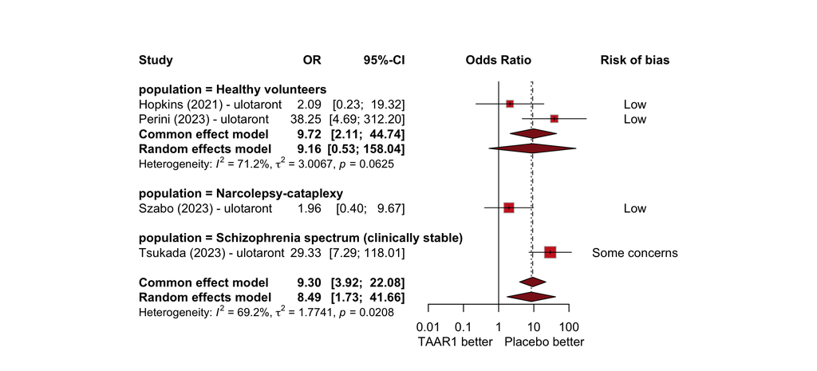

**Figure 17** Forest plot for any adverse events for the comparison of TAAR1 agonist vs. placebo at 1 day - 2 weeks.The overall risk of bias of the studies for this outcome is presented. OR=Odds ratio, 95%CI: 95% confidence intervals

#### Timepoint 2: *3 weeks - 13 weeks*

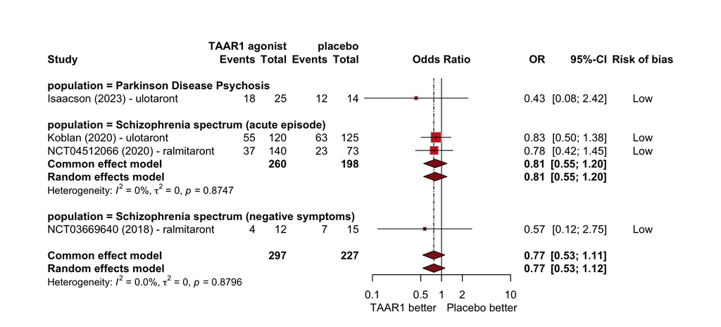

**Figure 18** Forest plot for any adverse event for the comparison of TAAR1 agonist vs. placebo at 3-13 weeks (primary timepoint). The overall risk of bias of the studies for this outcome is presented. OR=Odds ratio, 95%CI: 95% confidence intervals.

#### Timepoint 3: *> 13 weeks*

No usable data available from RCT.

### 6.1.15 Anticholinergic symptoms

#### Timepoint 1: *1 day - 2 weeks*

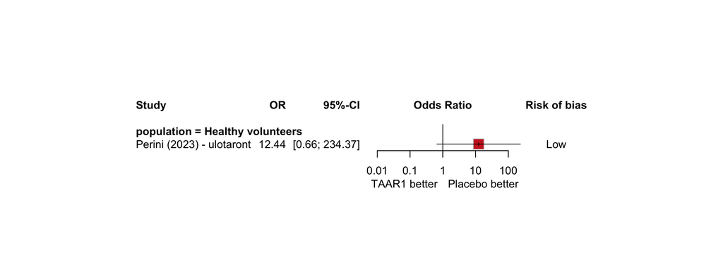

**Figure 19** Forest plot for anticholinergic side-effects (i.e., dry mouth in this study) for the comparison of TAAR1 agonist vs. placebo at 1 day - 2 weeks. The overall risk of bias of the studies for this outcome is presented. OR=Odds ratio, 95%CI: 95% confidence intervals.

#### Timepoint 2: *3 weeks - 13 week*

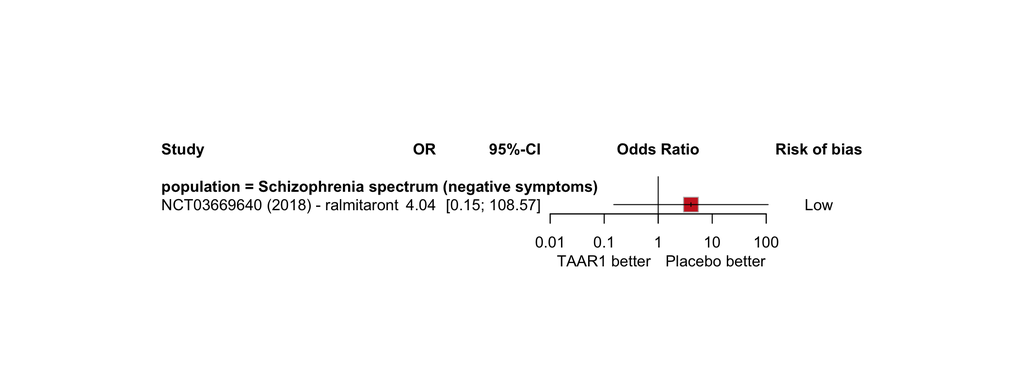

**Figure 20** Forest plot for anticholinergic side-effects (i.e., constipation in this study) for the comparison of TAAR1 agonist vs. placebo at 3-13 weeks. The overall risk of bias of the studies for this outcome is presented. OR=Odds ratio, 95%CI: 95% confidence intervals.

#### Timepoint 3: *> 13 weeks*

No usable data available from RCT.

### 6.1.16 Hypotension

#### Timepoint 1: *1 day - 2 weeks*

No usable data available from RCT.

#### Timepoint 2: *3 weeks - 13 weeks*

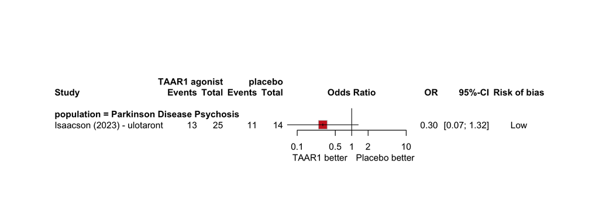

**Figure 21** Forest plot for hypotension for the comparison of TAAR1 agonist vs. placebo at 3-13 weeks (primary timepoint). The overall risk of bias of the studies for this outcome is presented. OR=Odds ratio, 95%CI: 95% confidence intervals.

#### Timepoint 3: *> 13 weeks*

No usable data available from RCT.

### 6.1.17 Dizziness

#### Timepoint 1: *1 day - 2 weeks*

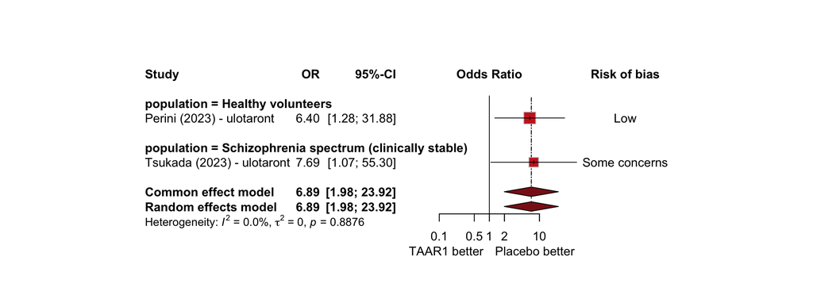

**Figure 22** Forest plot for dizziness for the comparison of TAAR1 agonist vs. placebo at 1 day - 2 weeks. The overall risk of bias of the studies for this outcome is presented. OR=Odds ratio, 95%CI: 95% confidence intervals.

#### Timepoint 2: *3 weeks - 13 weeks*

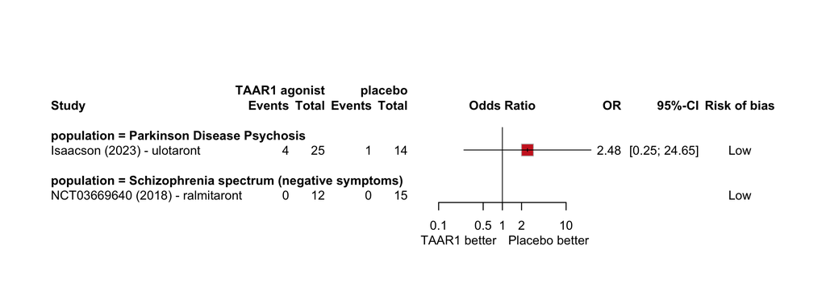

**Figure 23** Forest plot for dizziness for the comparison of TAAR1 agonist vs. placebo at 3-13 weeks (primary timepoint). The overall risk of bias of the studies for this outcome is presented. OR=Odds ratio, 95%CI: 95% confidence intervals.

#### Timepoint 3: *> 13 weeks*

No usable data available from RCT.

### 6.1.18 Nausea or vomiting

#### Timepoint 1: *1 day - 2 weeks*

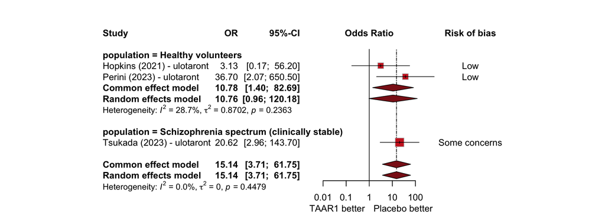

**Figure 24** Forest plot for nausea or vomiting for the comparison of TAAR1 agonist vs. placebo at 1 day - 2 weeks. The overall risk of bias of the studies for this outcome is presented. OR=Odds ratio, 95%CI: 95% confidence intervals.

#### Timepoint 2: *3 weeks - 13 weeks*

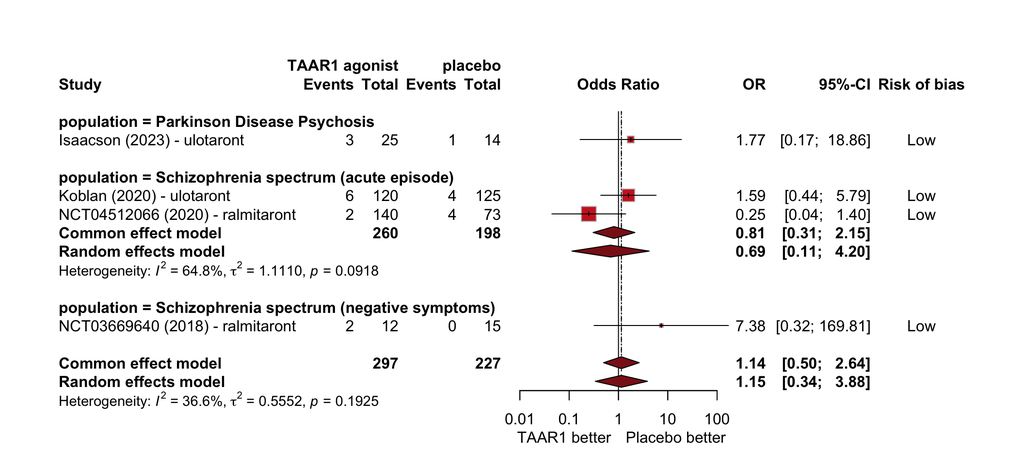

**Figure 25** Forest plot for nausea or vomiting for the comparison of TAAR1 agonist vs. placebo at 3-13 weeks (primary timepoint). The overall risk of bias of the studies for this outcome is presented. OR=Odds ratio, 95%CI: 95% confidence intervals.

It should be noted that there might be some heterogeneity in the findings between ulotaront and ralmitaront. This heterogeneity may potentially be driven by the fact that ulotaront is also a 5-HT1A receptor partial agonist, which is associated with gastrointestinal symptoms.

#### Timepoint 3: *> 13 weeks*

No usable data available from RCT.

### 6.1.19 QTc prolongation

#### Timepoint 1: *1 day - 2 weeks*

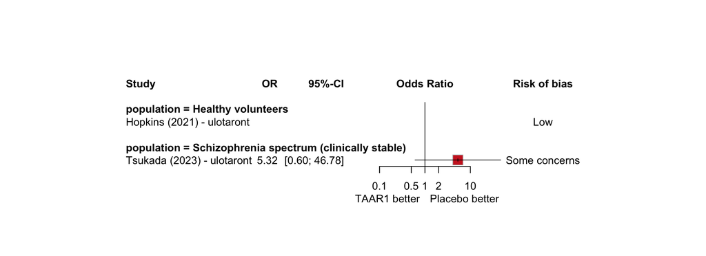

**Figure 26** Forest plot for QTc prolongation for the comparison of TAAR1 agonist vs. placebo at 1 day - 2 weeks. Studies with not estimable effect sizes had 0 events in both groups. The overall risk of bias of the studies for this outcome is presented. OR=Odds ratio, 95%CI: 95% confidence intervals.

#### Timepoint 2: *3 weeks - 13 weeks*

There were available data in Koblan et al. (2020) , which reported 0 events in both groups, so that an effect size cannot be estimated with the current approach.

#### Timepoint 3: *> 13 weeks*

No usable data available from RCT.

### 6.1.20 QTc interval in msec

#### Timepoint 1: *1 day - 2 weeks*

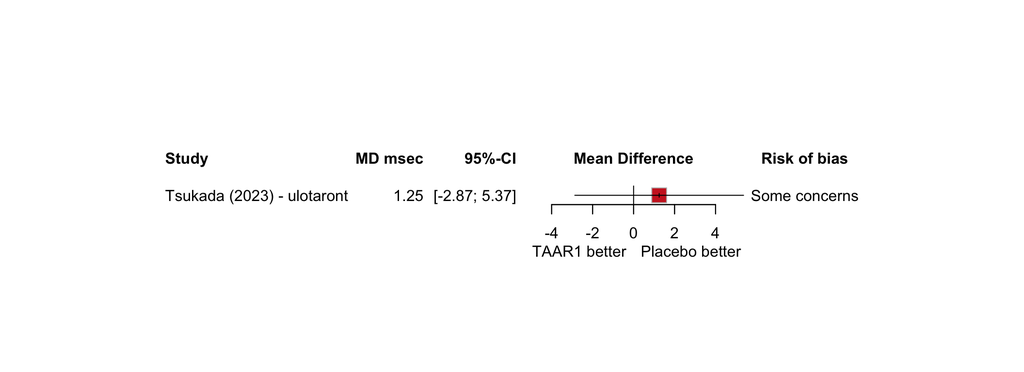

**Figure 27** Forest plot for QTc interval in msec for the comparison of TAAR1 agonist vs. placebo at 1 day - 2 weeks. The overall risk of bias of the studies for this outcome is presented. MD:Mean difference, 95%CI: 95% confidence intervals

#### Timepoint 2: *3 weeks - 13 weeks*

No usable data available from RCT.

#### Timepoint 3: *> 13 weeks*

No usable data available from RCT.

### 6.1.21 Weight increased

#### Timepoint 1: *1 day - 2 weeks*

No usable data available from RCT.

#### Timepoint 2: *3 weeks - 13 weeks*

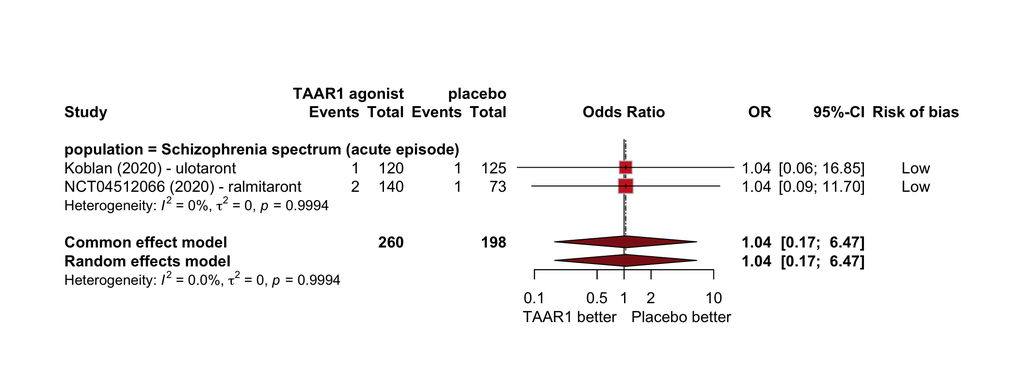

**Figure 28** Forest plot for weight gain for the comparison of TAAR1 agonist vs. placebo at 3-13 weeks (primary timepoint). The overall risk of bias of the studies for this outcome is presented. OR=Odds ratio, 95%CI: 95% confidence intervals.

#### Timepoint 3: *> 13 weeks*

No usable data available from RCT.

### 6.1.22 Weight in kg

#### Timepoint 1: *1 day - 2 weeks*

No usable data available from RCT.

#### Timepoint 2: *3 weeks - 13 weeks*

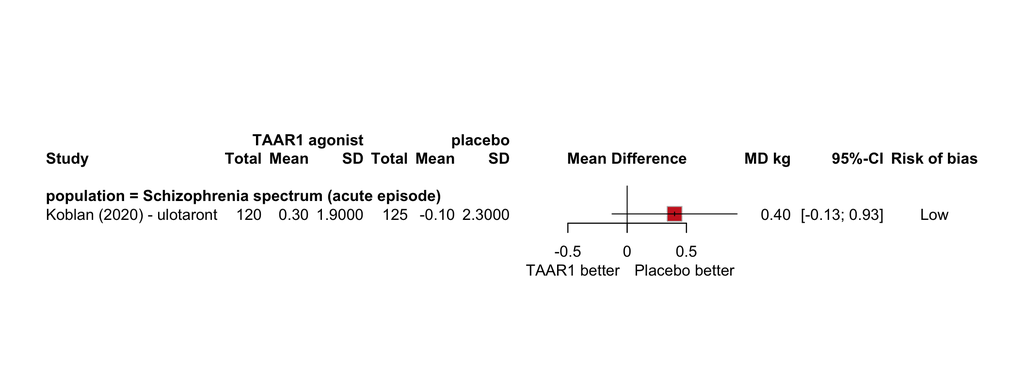

**Figure 29** Forest plot for weight change in kg for the comparison of TAAR1 agonist vs. placebo at 3-13 weeks (primary timepoint). The overall risk of bias of the studies for this outcome is presented. MD:Mean difference, SD: standard deviation, 95%CI: 95% confidence intervals.

#### Timepoint 3: *> 13 weeks*

No usable data available from RCT.

### 6.1.23 Hyperprolactinemia

#### Timepoint 1: *1 day - 2 weeks*

There were available data from one study (Hopkins, Dedic, and Koblan 2021) reporting 0 events in both arms so that an effect size cannot be estimated with the current approach.

#### Timepoint 2: *3 weeks - 13 weeks*

No usable data available from RCT.

#### Timepoint 3: *> 13 weeks*

No usable data available from RCT.

### 6.1.24 Prolactin levels in ng/ml

#### Timepoint 1: *1 day - 2 weeks*

No usable data available from RCT.

#### Timepoint 2: *3 weeks - 13 weeks*

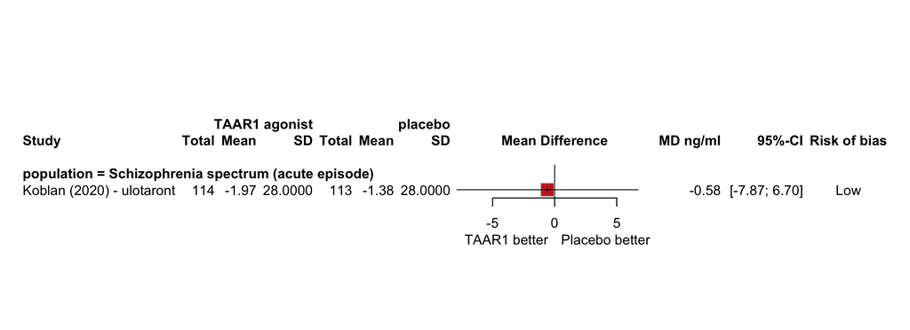

**Figure 30** Forest plot for prolactin levels in ng/ml for the comparison of TAAR1 agonist vs. placebo at 3-13 weeks (primary timepoint). SD was imputed from the dataset of antipsychotic trials in Huhn et al 2021. The overall risk of bias of the studies for this outcome is presented. MD:Mean difference, SD=Standard deviation, 95%CI: 95% confidence intervals.

#### Timepoint 3: *> 13 weeks*

No usable data available from RCT.

### 6.1.25 Akathisia

Terms considered included: restlessness (when was used to describe akathisia)

#### Timepoint 1: *1 day - 2 weeks*

No usable data available from RCT.

#### Timepoint 2: *3 weeks - 13 weeks*

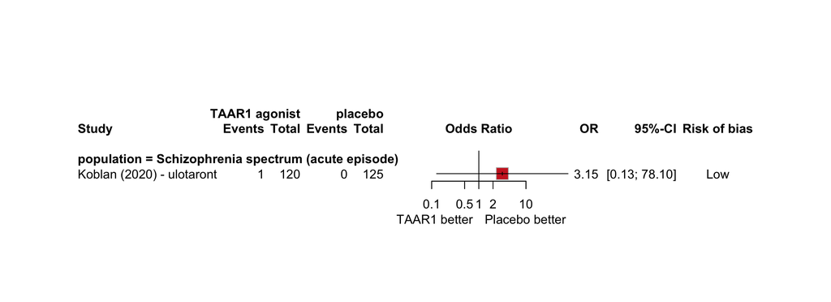

**Figure 31** Forest plot for akathisia for the comparison of TAAR1 agonist vs. placebo at 3-13 weeks (primary timepoint). The overall risk of bias of the studies for this outcome is presented. OR: Odds ratio, 95%CI: 95% confidence intervals.

#### Timepoint 3: *> 13 weeks*

No usable data available from RCT.

### 6.1.26 Extrapyramidal symptoms

#### Timepoint 1: *1 day - 2 weeks*

No usable data available from RCT.

#### Timepoint 2: *3 weeks - 13 weeks*

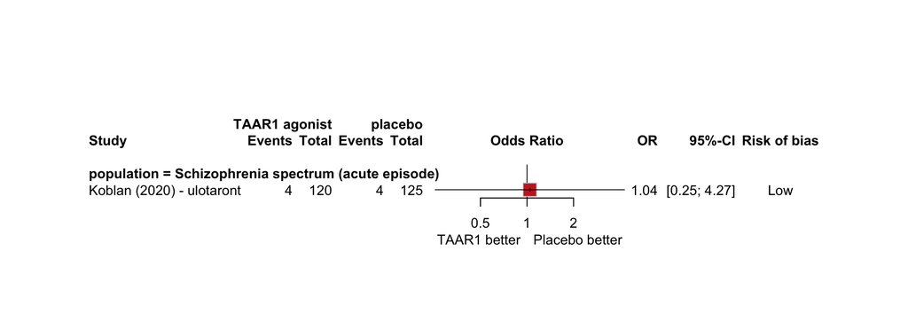

**Figure 32** Forest plot for extrapyramidal side effects (use of antiparkinsonian medication as a proxy) for the comparison of TAAR1 agonist vs. placebo at 3-13 weeks (primary timepoint). The overall risk of bias of the studies for this outcome is presented. MD:Mean difference, SD: standard deviation, 95%CI: 95% confidence intervals. Furthermore, there were narrative descriptions from a conference abstract (“ACNP 62(nd) Annual Meeting: Poster Abstracts P251 - P500” 2023) that ulotaront did not differ from placebo in extrapyramidal symptoms with low absolute frequencies in two unpublished phase III trials (Sumitomo Pharma America 2023b, 2023c). Moreover, ulotaront was reported not to deteriorate movement symptoms in participants with Parkinson’s disease psychosis as measured with the Unified Parkinson Disease Rating Scale Part III (Isaacson et al. 2023).

#### Timepoint 3: *> 13 weeks*

No usable data available from RCT.

### 6.1.28 Anxiety

#### Timepoint 1: *1 day - 2 weeks*

There were usable data for one study (Perini et al. 2023), which reported 0 events in both groups so that an effect size could not be estimated with the current approach.

#### Timepoint 2: *3 weeks - 13 weeks*

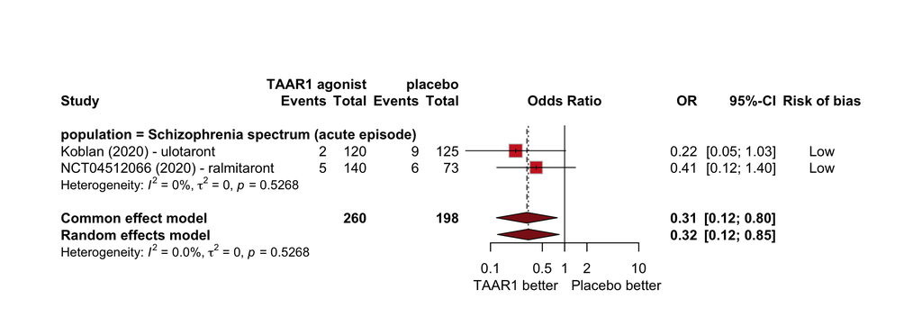

**Figure 33** Forest plot for anxiety as adverse event for the comparison of TAAR1 agonist vs. placebo at 3-13 weeks (primary timepoint). The overall risk of bias of the studies for this outcome is presented. OR: Odds ratio, 95%CI: 95% confidence intervals.

#### Timepoint 3: *> 13 weeks*

No usable data available from RCT.

### 6.1.29 Agitation

#### Timepoint 1: *1 day - 2 weeks*

No usable data available from RCT.

#### Timepoint 2: *3 weeks - 13 weeks*

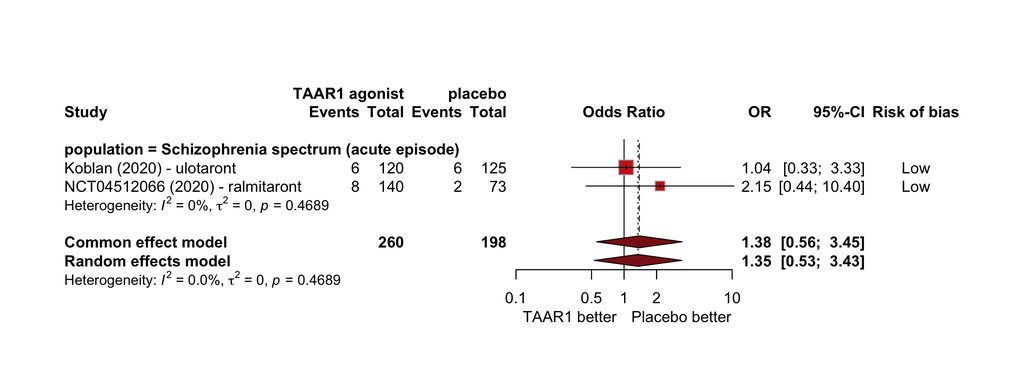

**Figure 34** Forest plot for agitation for the comparison of TAAR1 agonist vs. placebo at 3-13 weeks (primary timepoint). The overall risk of bias of the studies for this outcome is presented. OR: Odds ratio, 95%CI: 95% confidence intervals.

#### Timepoint 3: *> 13 weeks*

No usable data available from RCT.

### 6.1.30 Headache

#### Timepoint 1: *1 day - 2 weeks*

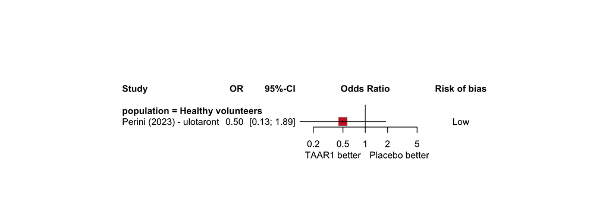

**Figure 35** Forest plot for headache for the comparison of TAAR1 agonist vs. placebo at 1 day to 2 weeks. The overall risk of bias of the studies for this outcome is presented. OR: Odds ratio, 95%CI: 95% confidence intervals.

#### Timepoint 2: *3 weeks - 13 weeks*

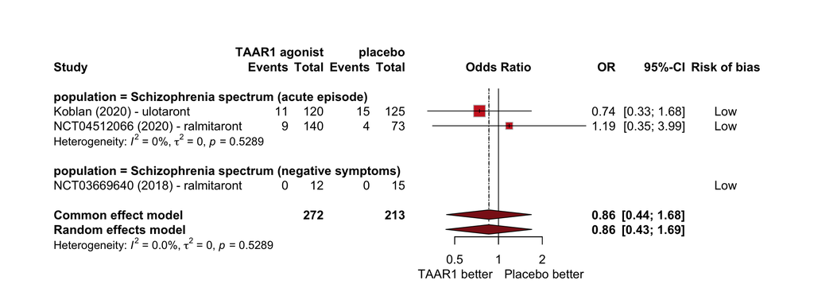

**Figure 36** Forest plot for headache for the comparison of TAAR1 agonist vs. placebo at 3-13 weeks (primary timepoint). The overall risk of bias of the studies for this outcome is presented. Studies with not estimable effect sizes had 0 events in both groups. OR: Odds ratio, 95%CI: 95% confidence intervals.

#### Timepoint 3: *> 13 weeks*

No usable data available from RCT.

### 6.1.30 Sedation

Terms that were considered as reported in the trials: fatigue, sedation, somnolence

#### Timepoint 1: *1 day - 2 weeks*

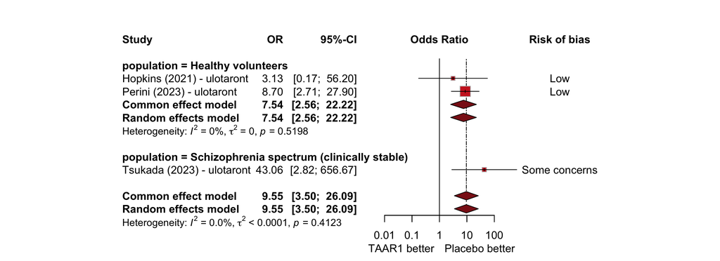

**Figure 37** Forest plot for sedation for the comparison of TAAR1 agonist vs. placebo at 1 day to 2 weeks. The overall risk of bias of the studies for this outcome is presented. OR: Odds ratio, 95%CI: 95% confidence intervals.

#### Timepoint 2: *3 weeks - 13 weeks*

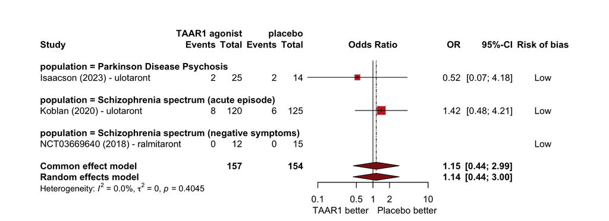

**Figure 38** Forest plot for sedation for the comparison of TAAR1 agonist vs. placebo at 3-13 weeks (primary timepoint). The overall risk of bias of the studies for this outcome is presented. Studies with not estimable effect sizes had 0 events in both groups. OR: Odds ratio, 95%CI: 95% confidence intervals.

#### Timepoint 3: *> 13 weeks*

No usable data available from RCT.

### 6.1.31 Insomnia

#### Timepoint 1: *1 day - 2 weeks*

No usable data available from RCT.

#### Timepoint 2: *3 weeks - 13 weeks*

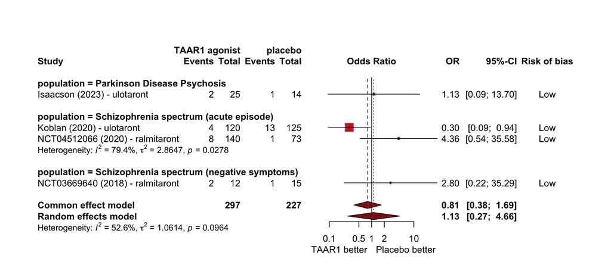

**Figure 39** Forest plot for insomnia for the comparison of TAAR1 agonist vs. placebo at 3-13 weeks (primary timepoint). The overall risk of bias of the studies for this outcome is presented. The overall risk of bias of the studies for this outcome is presented. OR: Odds ratio, 95%CI: 95% confidence intervals.

#### Timepoint 3: *> 13 weeks*

No usable data available from RCT.

### 6.1.32 Summary outcome plots

#### Efficacy outcomes

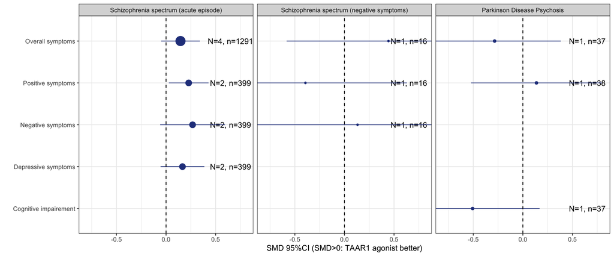

It should be noted that there were also data for relapse that are not displayed in this figure (see instead 2.5.9).

#### Dropouts and side-effects

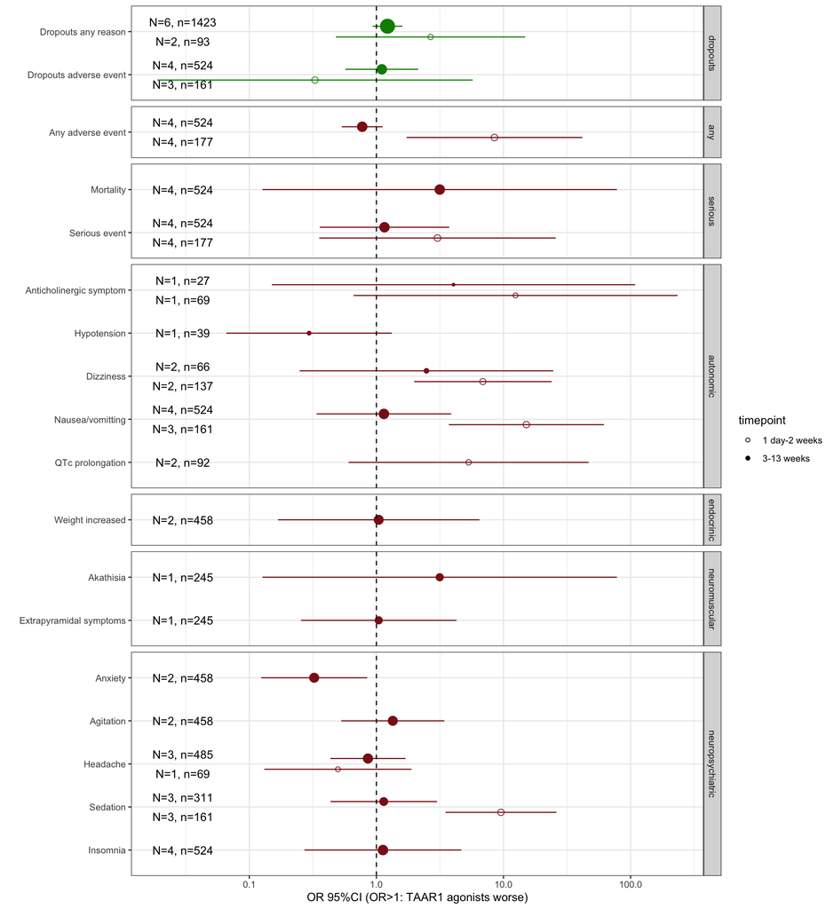

**Figure 41** Summary forest plot for dropouts and side-effects for the comparison of TAAR1 agonists compared to placebo and for the two timepoints with usable data. It should be noted that different populations have been pooled in the analysis of dropouts and adverse events including schizophrenia (acute phase, negative symptoms), Parkinson’s disease psychosis, narcolepsy-cateplexy and healthy volunteers. The size is proportional to the number of participants in the analysis. The findings of the random-effects model are presented. OR>1 corresponds to more events with TAAR1 agonists compared to placebo. OR: Odds ratio, 95%CI: 95% confidence intervals. N=number of studies, n=number of participants.

## 6.2 *TAAR1 agonist* vs *antipsychotic (monotherapy)*

### 6.2.1 Overall symptoms (primary outcome)

#### Timepoint 1: *1 day - 2 weeks*

No usable data available from RCT.

#### Timepoint 2: *3 weeks - 13 weeks*

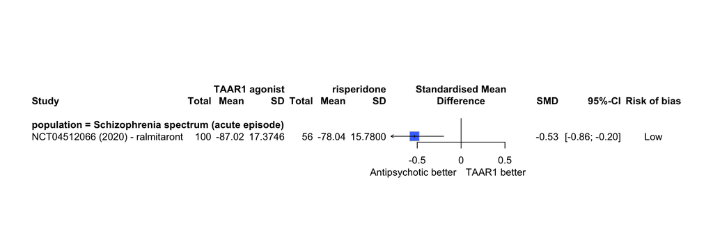

**Figure 42** Forest plot for overall symptoms (primary outcome, measured with PANSS total) for the comparison of TAAR1 agonist vs. antipsychotics at 3-13 weeks (primary timepoint). The overall risk of bias of the studies for this outcome is presented. SMD: Standardized mean difference, SD: Standard deviation, 95%CI: 95% confidence interval.

#### Timepoint 3: *> 13 weeks*

No usable data available from RCT.

### 6.2.2 Positive symptoms

#### Timepoint 1: *1 day - 2 weeks*

No usable data available from RCT.

#### Timepoint 2: *3 weeks - 13 weeks*

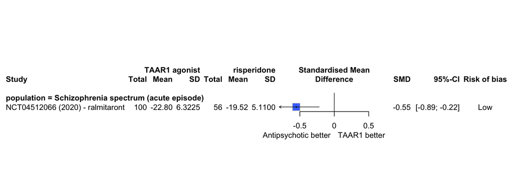

**Figure 43** Forest plot for positive symptoms for the comparison of TAAR1 agonist vs. antipsychotics (measured with PANSS positive) at 3-13 weeks (primary timepoint). The overall risk of bias of the studies for this outcome is presented. SMD: Standardized mean difference, SD: Standard deviation, 95%CI: 95% confidence interval.

#### Timepoint 3: *> 13 weeks*

No usable data available from RCT.

### 6.2.3 Negative symptoms

#### Timepoint 1: *1 day - 2 weeks*

No usable data available from RCT.

#### Timepoint 2: *3 weeks - 13 weeks*

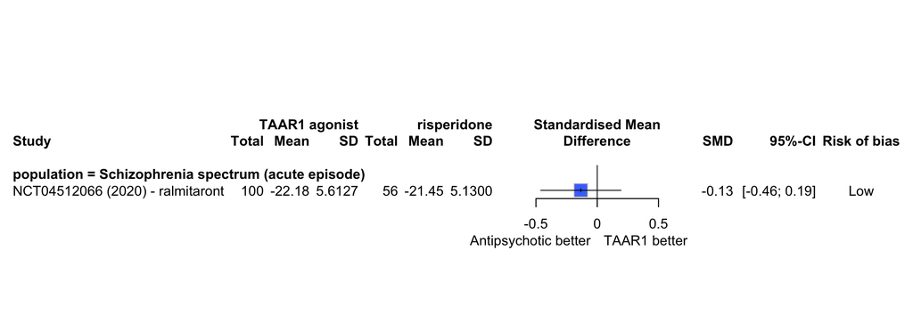

**Figure 44** Forest plot for negative symptoms for the comparison of TAAR1 agonist vs. antipsychotics (measured with PANSS negative) at 3-13 weeks (primary timepoint). The overall risk of bias of the studies for this outcome is presented. SMD: Standardized mean difference, SD: Standard deviation, 95%CI: 95% confidence interval.

#### Timepoint 3: *> 13 weeks*

No usable data available from RCT.

### 6.2.4 Depressive symptoms

#### Timepoint 1: *1 day - 2 weeks*

No usable data available from RCT.

#### Timepoint 2: *3 weeks - 13 weeks*

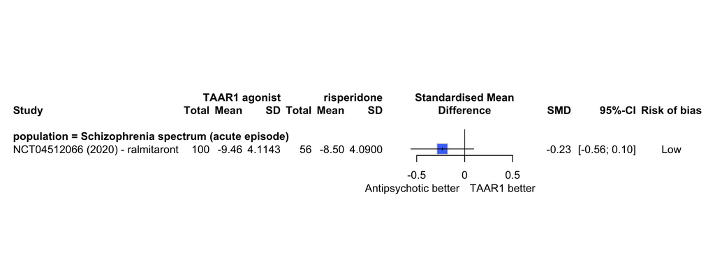

**Figure 45** Forest plot for depression symptoms for the comparison of TAAR1 agonist vs. antipsychotics (measured with PANSS anxiety/depression factor) at 3-13 weeks (primary timepoint). The overall risk of bias of the studies for this outcome is presented. SMD: Standardized mean difference, SD: Standard deviation, 95%CI: 95% confidence interval.

#### Timepoint 3: *> 13 weeks*

No usable data available from RCT.

### 6.2.5 Cognitive symptoms

#### Timepoint 1: *1 day - 2 weeks*

No usable data available from RCT.

#### Timepoint 2: *3 weeks - 13 weeks*

No usable data available from RCT.

#### Timepoint 3: *> 13 weeks*

No usable data available from RCT.

### 6.2.6 Quality of life

#### Timepoint 1: *1 day - 2 weeks*

No usable data available from RCT.

#### Timepoint 2: *3 weeks - 13 weeks*

No usable data available from RCT.

#### Timepoint 3: *> 13 weeks*

No usable data available from RCT.

### 6.2.7 Functioning

#### Timepoint 1: *1 day - 2 weeks*

No usable data available from RCT.

#### Timepoint 2: *3 weeks - 13 weeks*

No usable data available from RCT.

#### Timepoint 3: *> 13 weeks*

No usable data available from RCT.

### 6.2.8 Response to treatment

#### Timepoint 1: *1 day - 2 weeks*

No usable data available from RCT.

#### Timepoint 2: *3 weeks - 13 weeks*

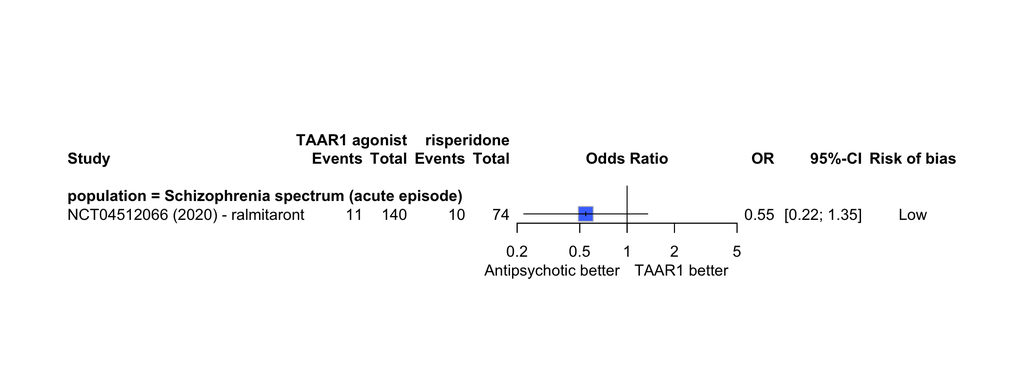

**Figure 46** Forest plot for response to treatment (>50% symptom reduction in PANSS total from baseline) for the comparison of TAAR1 agonist vs. antipsychotics at 3-13 weeks (primary timepoint). The overall risk of bias of the studies for this outcome is presented. OR: Odds ratio, 95%CI: 95% confidence interval.

#### Timepoint 3: *> 13 weeks*

No usable data available from RCT.

### 6.2.9 Relapse

#### Timepoint 1: *1 day - 2 weeks*

No usable data available from RCT.

#### Timepoint 2: *3 weeks - 13 weeks*

No usable data available from RCT.

#### Timepoint 3: *> 13 weeks*

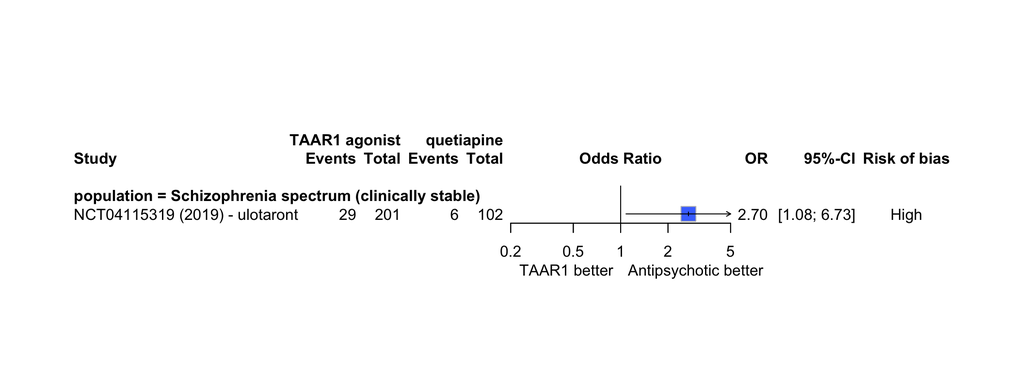

**Figure 47** Forest plot for relapse (defined as adverse event “schizophrenia”) for the comparison of TAAR1 agonist vs. antipsychotics at more than 13 weeks. The overall risk of bias of the studies for this outcome is presented. OR: Odds ratio, 95%CI: 95% confidence interval.

It should be noted that data from this trial were available only from a conference abstract (SIRS 2024), which focused on reporting safety and tolerability and mentioned, without presenting quantitative data, that there were no differences between groups in the changes of PANSS total and subscale scores.

### 6.2.10 Dropouts due to any reason

#### Timepoint 1: *1 day - 2 weeks*

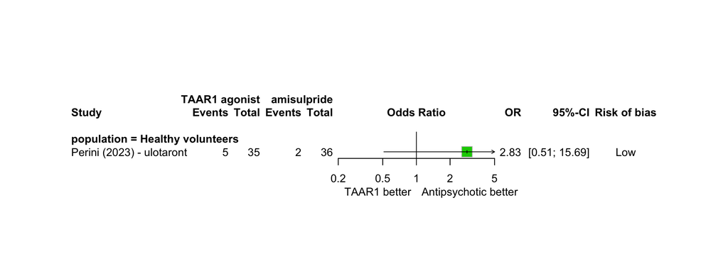

**Figure 48** Forest plot for dropouts due to any reason for the comparison of TAAR1 agonist vs. antipsychotics at 1 day to 2 weeks. The overall risk of bias of the studies for this outcome is presented. OR: Odds ratio, 95%CI: 95% confidence interval.

#### Timepoint 2: *3 weeks - 13 weeks*

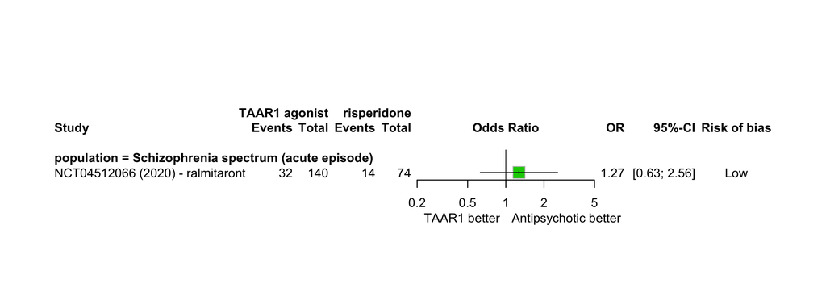

**Figure 49** Forest plot for dropouts due to any reason for the comparison of TAAR1 agonist vs. antipsychotics at 3-13 weeks (primary timepoint). The overall risk of bias of the studies for this outcome is presented. OR: Odds ratio, 95%CI: 95% confidence interval.

#### Timepoint 3: *> 13 weeks*

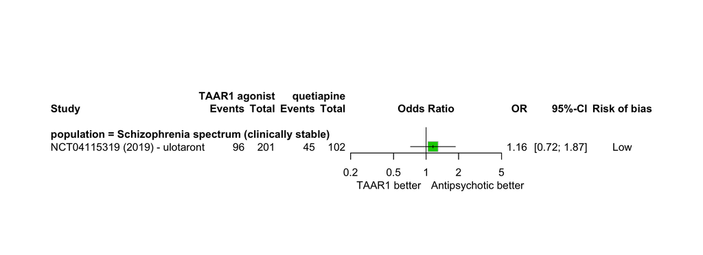

**Figure 50** Forest plot for dropouts due to any reason for the comparison of TAAR1 agonist vs. antipsychotics at >13 weeks. The overall risk of bias of the studies for this outcome is presented. OR: Odds ratio, 95%CI: 95% confidence interval.

### 6.2.11 Dropouts due to adverse event

#### Timepoint 1: *1 day - 2 weeks*

There were usable data in (Perini et al. 2023), which reported 0 events in both groups and an effect size cannot be estimated with the current approach.

#### Timepoint 2: *3 weeks - 13 weeks*

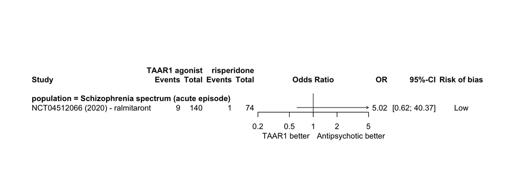

**Figure 51** Forest plot for dropouts due to adverse events for the comparison of TAAR1 agonist vs. antipsychotics at 3-13 weeks (primary timepoint). The overall risk of bias of the studies for this outcome is presented. OR: Odds ratio, 95%CI: 95% confidence interval.

#### Timepoint 3: *> 13 weeks*

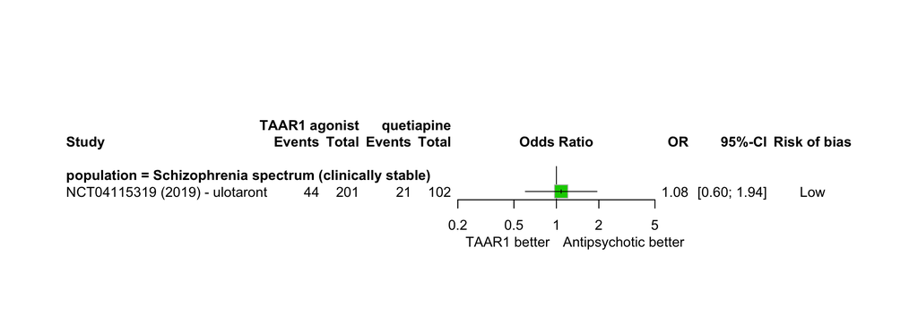

### 6.2.12 Serious adverse event

#### Timepoint 1: *1 day - 2 weeks*

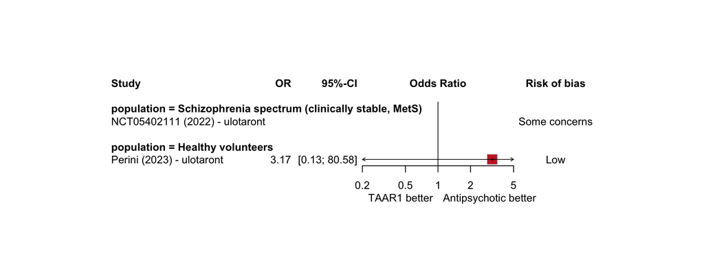

**Figure 53** Forest plot for serious adverse events for the comparison of TAAR1 agonist vs. antipsychotics at 1 day to 2 weeks. The comparison groups were previous antipsychotics (NCT05402111) or amisulpride (Perini et al 2023). The overall risk of bias of the studies for this outcome is presented. Studies with no estimable effect size had 0 events in both arms. OR: Odds ratio, MetS: Metabolic Syndrome, 95%CI: 95% confidence interval.

#### Timepoint 2: *3 weeks - 13 weeks*

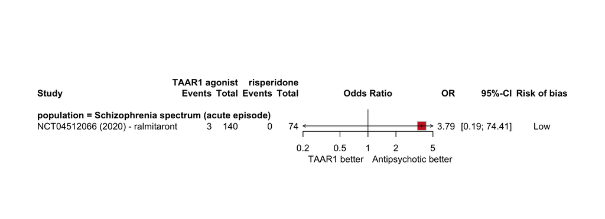

**Figure 54** Forest plot for serious adverse events for the comparison of TAAR1 agonist vs. antipsychotics at 3-13 weeks (primary timepoint). The overall risk of bias of the studies for this outcome is presented. OR: Odds ratio, 95%CI: 95% confidence interval.

#### Timepoint 3: *> 13 weeks*

No usable data available from RCT.

### 6.2.13 Death

#### Timepoint 1: *1 day - 2 weeks*

There were usable data in (Perini et al. 2023; Milanović et al. 2024), which reported 0 events in both groups and an effect size cannot be estimated with the current approach.

#### Timepoint 2: *3 weeks - 13 weeks*

There were usable data in (Roche 2022), which reported 0 events in both groups and an effect size cannot be estimated with the current approach.

#### Timepoint 3: *> 13 weeks*

No usable data available from RCT.

### 6.2.14 Any adverse event

#### Timepoint 1: *1 day - 2 weeks*

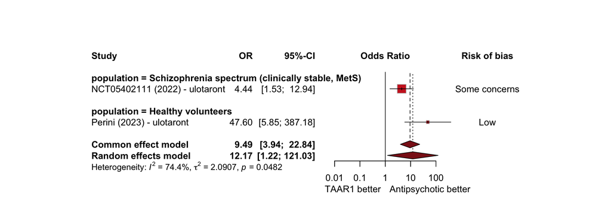

**Figure 55** Forest plot for any adverse event for the comparison of TAAR1 agonist vs. antipsychotics at 1 day to 2 weeks. The comparison groups were previous antipsychotics (NCT05402111) or amisulpride (Perini et al 2023). The overall risk of bias of the studies for this outcome is presented. OR: Odds ratio, MetS: Metabolic Syndrome, 95%CI: 95% confidence interval.

#### Timepoint 2: *3 weeks - 13 weeks*

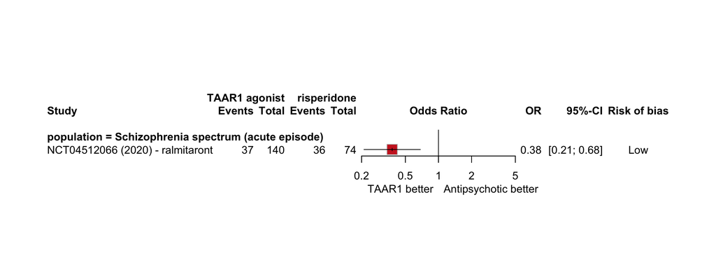

**Figure 56** Forest plot for any adverse event for the comparison of TAAR1 agonist vs. antipsychotics at 3-13 weeks (primary timepoint). The overall risk of bias of the studies for this outcome is presented. OR: Odds ratio, 95%CI: 95% confidence interval.

#### Timepoint 3: *> 13 weeks*

No usable data available from RCT.

### 6.2.15 Anticholinergic symptoms

#### Timepoint 1: *1 day - 2 weeks*

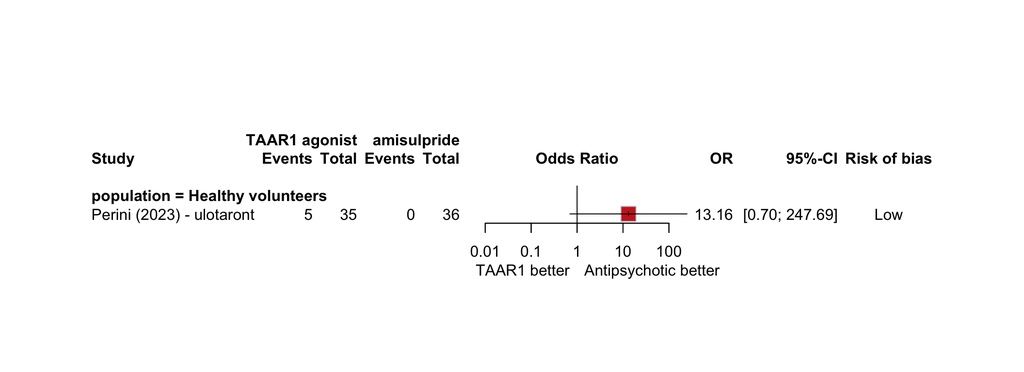

**Figure 57** Forest plot for anticholinergic side effects (e.g., dry mouth in this study) for the comparison of TAAR1 agonist vs. antipsychotics at 1 day to 2 weeks. The overall risk of bias of the studies for this outcome is presented. OR: Odds ratio, 95%CI: 95% confidence interval.

#### Timepoint 2: *3 weeks - 13 weeks*

No usable data available from RCT.

#### Timepoint 3: *> 13 weeks*

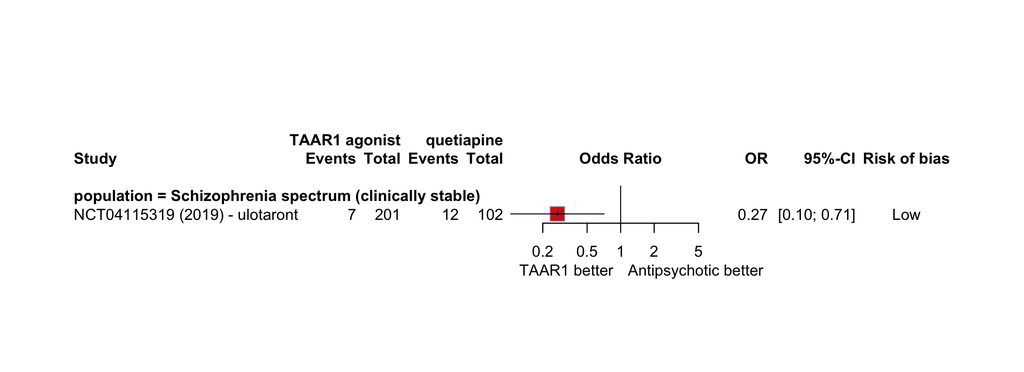

**Figure 58** Forest plot for anticholinergic side effects (e.g., constipation reported) for the comparison of TAAR1 agonist vs. antipsychotics at >13 weeks. The overall risk of bias of the studies for this outcome is presented. OR: Odds ratio, 95%CI: 95% confidence interval.